# Synthetische Gehirne, 3D-CNNs und LRP

### Ein kommentiertes Notebook für Deep-Learning-Einsteiger

**Worum geht es hier?**

Dieses Notebook baut ein komplettes Experiment in vier Schritten:

1. Es **erzeugt** einen künstlichen 3D-Datensatz: kugelförmige "Gehirne", in die Tunnel gebohrt werden. Die Tunnelbreite ist bekannt und dient als Zielwert.
2. Es **trainiert** ein 3D-CNN (Convolutional Neural Network), das aus dem Volumen die Tunnelbreite vorhersagen soll — eine *Regression*, keine Klassifikation.
3. Es **erklärt** die Vorhersagen mit *Layer-wise Relevance Propagation* (LRP): Welche Voxel haben die Vorhersage nach oben, welche nach unten getrieben?
4. Es **prüft** die Erklärungen mit kausalen Eingriffen (mehr Tunnel bohren, Tunnel verbreitern) und schaut in die interne Repräsentation des Netzes.

**Warum synthetische Daten? Der größere Kontext.**

Das eigentliche Ziel des Projekts (siehe die Schwester-Notebooks `Explain_brain_age_predictions`) ist *Brain-Age-Prediction*: Aus einem echten MRT-Volumen soll ein Netz das Alter einer Person schätzen. Dort stellt sich sofort die Vertrauensfrage — schaut das Netz auf plausible anatomische Strukturen, oder auf Artefakte des Scanners?

Das Problem: bei echten MRT-Daten kennen wir die "richtige" Erklärung nicht. Wir können also nie sagen, ob eine schöne Heatmap tatsächlich korrekt ist. Deshalb der Trick dieses Notebooks: Wir bauen ein Spielzeugproblem, bei dem wir die Ground Truth der Erklärung **per Konstruktion kennen** — der Zielwert hängt ausschließlich von der Tunnelbreite ab. Eine gute Erklärungsmethode *muss* also die Tunnelränder markieren und nicht etwa den Bildhintergrund. Damit wird die XAI-Methode selbst validierbar. Dieses Vorgehen heißt in der Literatur *sanity check* bzw. *ground-truth-based evaluation of attribution methods*.

> **Wichtiger Hinweis zu diesem Notebook-Durchlauf:** Beide Modelle wurden hier mit `epochs=2` trainiert (im Original: 500). Das ist eine Debug-Einstellung, damit der Durchlauf Minuten statt Stunden dauert. Die Modelle sind deshalb **massiv untertrainiert**, und alle Heatmaps zeigen ein Netz, das die Aufgabe noch kaum gelöst hat. Für die didaktische Frage "*wie liest man solche Bilder?*" ist das kein Problem — man muss die Ergebnisse nur ehrlich als "Zwischenstand" lesen. An den entsprechenden Stellen unten steht jeweils dabei, was man bei einem austrainierten Modell erwarten würde.

## Inhaltsverzeichnis

| # | Abschnitt | Thema |
| --- | --- | --- |
| 1 | Datengenerierung: synthetische Gehirne mit Tunneln | Daten |
| 2 | Zwischenstopp: der Kernel lebt noch | Daten |
| 3 | 3D-Visualisierung: Volume Rendering | Daten |
| 4 | 3D-Visualisierung: Isosurface | Daten |
| 5 | Aufteilung in Trainings-, Validierungs- und Testdaten | Daten |
| 6 | Noch ein Zwischenstopp | Daten |
| 7 | Modell 1: 3D-CNN mit Global Average Pooling | Modell |
| 8 | Training und Lernkurven | Modell |
| 9 | Wie gut sagt das Modell vorher? | Modell |
| 10 | LRP: Grundidee und erste Heatmaps | XAI |
| 11 | Kausaler Test 1: immer mehr Tunnel bohren | XAI |
| 12 | Kausaler Test 2: breite vs. schmale Tunnel | XAI |
| 13 | LRP über das gesamte Volumen | XAI |
| 14 | Der Bottleneck als Repräsentation | XAI |
| 15 | Kontrastive Erklärungen mit RestructuredLRP | XAI |
| 16 | Neuronenweise LRP im Bottleneck | XAI |
| 17 | Wie redundant sind die 32 Features? | XAI |
| 18 | Modell 2: ohne GAP, mit fixiertem Bias | Modell |
| 19 | Training von Modell 2 | Modell |
| 20 | LRP für Modell 2 | XAI |
| 21 | Neuronenweise LRP für Modell 2 | XAI |
| 22 | Korrelationen in Modell 2 und tote ReLUs | XAI |
| 23 | Reproduzierbarkeitscheck | XAI |
| 24 | Referenz-Encodings für Modell 2 | XAI |
| 25 | Fazit und Ausblick | Zusammenfassung |

### Vokabelliste für den Einstieg

| Begriff | Bedeutung in diesem Notebook |
| --- | --- |
| **Voxel** | ein Bildpunkt in 3D (das 3D-Äquivalent zum Pixel) |
| **Volumen** | ein Datenpunkt: ein $32\times32\times32$-Würfel mit einem Grauwert pro Voxel |
| **Regression** | das Netz gibt eine *Zahl* aus (hier: Tunnelbreite 1–10), keine Klasse |
| **Conv3D** | Faltungsschicht, die mit einem $3\times3\times3$-Filter über das Volumen fährt |
| **Pooling** | Verkleinern der Auflösung (hier: von $32^3$ auf $16^3$ auf $8^3$ auf $4^3$) |
| **Bottleneck** | die schmalste Schicht vor der Ausgabe (hier: 32 Neuronen) — die "Zusammenfassung" des Volumens |
| **Relevanz / Heatmap** | pro Voxel eine Zahl: wie stark hat dieser Voxel die Vorhersage beeinflusst |
| **LRP** | Layer-wise Relevance Propagation: das Erklärungsverfahren dieses Repos |

## 1. Datengenerierung: synthetische Gehirne mit Tunneln

↑ Inhaltsverzeichnis

### Zuerst: die technische Vorbereitung

Der obere Teil der Zelle hat noch nichts mit Daten zu tun, sondern richtet die Umgebung ein. Drei Dinge passieren dort:

1. **`find_repo_root()`** sucht vom aktuellen Arbeitsverzeichnis aus nach oben, bis eine `pyproject.toml` oder ein `explainability`-Ordner auftaucht, und legt diesen Pfad in `sys.path`. Das ist der Grund, warum `from explainability import LRP` funktioniert, egal aus welchem Verzeichnis das Notebook gestartet wurde.
2. **`find_notebook_name()`** ermittelt den Namen des laufenden Notebooks. Das ist überraschend fummelig, weil Jupyter diese Information nicht standardisiert bereitstellt: Die Funktion probiert der Reihe nach `ipynbname`, dann Umgebungsvariablen (`JPY_SESSION_NAME`, `__session__`), dann `__file__` (falls als Skript ausgeführt) und schließlich die Kommandozeilen der Elternprozesse über `/proc` (für `nbconvert`/`quarto`). Wer den Automatismus umgehen will, setzt die Umgebungsvariable `NOTEBOOK_NAME`.
3. **`target_dir`** wird daraus gebaut: `output/notebooks/<notebook-name>`. Dort landen später die trainierten Modelle (siehe Abschnitt 8). So schreibt jedes Notebook in seinen eigenen Ausgabeordner und Ergebnisse verschiedener Experimente vermischen sich nicht.

`np.random.seed(42)` fixiert den Zufallsgenerator. Damit ist der ganze Datensatz **reproduzierbar** — bei jedem Ausführen entstehen dieselben Gehirne. Für Experimente ist das unverzichtbar, weil man sonst nicht unterscheiden kann, ob ein Unterschied vom geänderten Code oder vom Zufall kommt.

### Was passiert in dieser Zelle?

Die Zelle erzeugt den kompletten Datensatz: `N = 1000` Volumen der Größe $32\times32\times32\times1$ (die letzte `1` ist der Farbkanal, analog zu einem Graustufenbild). Der Ablauf pro Volumen:

**Schritt 1 — die Kugel ("Gehirn").** `create_brain` legt eine Vollkugel in den Würfel. Mittelpunkt $c$ und Radius $r$ werden leicht zufällig gewählt:

$$c \sim \mathcal{U}\{14,\dots,17\}^3, \qquad r \sim \mathcal{U}\{10,\dots,13\}$$

Ein Voxel an Position $p$ gehört zum Gewebe, wenn $\lVert p - c\rVert_2 \le r$. Alle Gewebe-Voxel bekommen einen **zufälligen** Grauwert $\mathcal{U}(0.25,\,1)$, alles außerhalb bleibt $0$. Dieses Rauschen ist Absicht: es imitiert die Textur echter MRT-Bilder und verhindert, dass das Netz eine triviale Abkürzung über konstante Intensitäten findet.

**Schritt 2 — die Tunnel.** `drill` bohrt `NUM_TUNNELS = 6` Gänge. Jeder Tunnel startet an einem zufälligen Punkt der Kugeloberfläche und läuft grob Richtung Mittelpunkt. Die Laufrichtung wird bei jedem Schritt mit $\mathcal{N}(\mu,\,|\mu|/3)$ verrauscht — daraus entstehen die gekrümmten, unregelmäßigen Gänge statt gerader Bohrlöcher. An jeder Position wird eine kleine Kugel ("pocket") ausgeschnitten, also auf $0$ gesetzt, mit Radius

$$\rho \sim \mathcal{U}\big(\lfloor w/2 \rfloor,\, 1\big)$$

wobei $w$ das Label des Volumens ist. **Das ist der entscheidende Punkt:** je größer das Label $w$, desto größer die ausgeschnittenen Kugeln, desto breiter die Tunnel. Da das entfernte Volumen ungefähr mit $\rho^3$ skaliert, wächst der Gewebeverlust stark überproportional mit dem Label.

**Schritt 3 — die Labels.** `y = np.random.randint(1, MAX_RADIUS + 1, N)` zieht für jedes Volumen ein Label aus $\{1,\dots,10\}$ gleichverteilt. Das Netz soll später genau dieses $w$ zurückrechnen.

### Was ist die "Aufgabe" für das Netz?

Gesucht ist die Funktion $f: \mathbb{R}^{32\times32\times32} \to \mathbb{R}$ mit $f(X) \approx w$. Wichtig ist, was *nicht* zählt: Position der Tunnel, Anzahl der Tunnel (immer 6), Kugelgröße, Grauwertrauschen. Das sind alles **Störfaktoren** (nuisance variables), gegen die das Netz invariant sein muss. Nur die *lokale Breite* der Gänge trägt Information. Genau diese Trennung macht das Problem zu einem guten Prüfstand für Erklärungsmethoden.

### Die Grafik: 10 Zeilen × 8 Spalten

Am Ende der Zelle wird ein Gitter geplottet. Die Logik ist wichtig, um das Bild zu lesen:

- **Zeile $i$** = das *erste* Volumen im Datensatz mit Label $y = i$, also Zeile 1 = Tunnelbreite 1, Zeile 10 = Tunnelbreite 10.
- **Spalte $j$** = ein 2D-Schnitt (Slice) durch dasselbe Volumen, nämlich die Ebenen $z = 12 \dots 19$ — grob die Mitte des Würfels.

Man schaut also **nicht** auf 80 verschiedene Gehirne, sondern auf 10 Gehirne in je 8 Schnittbildern. Das ist die übliche Darstellung in der Bildgebung: ein 3D- Volumen wird als Stapel von 2D-Schichten gezeigt.

### Interpretation

- **Zeile 1 (Breite 1):** nahezu vollständige, gesprenkelte Scheiben. Die Tunnel sind so schmal, dass sie in einem Schnitt oft nur als einzelne schwarze Punkte oder feine Kratzer erscheinen (im Bild z. B. das kleine Kreuz in Spalte 6).
- **Zeilen 2–5:** deutlich erkennbare schwarze Löcher und Kanäle, die von außen nach innen laufen. Da ein Tunnel dreidimensional gekrümmt ist, sieht man denselben Gang in aufeinanderfolgenden Schnitten wandern — er "bewegt" sich von Spalte zu Spalte.
- **Zeilen 6–10:** die Kugel wird regelrecht ausgehöhlt. In Zeile 6 und Zeile 10 bleiben nur noch Sicheln und Fragmente übrig; in Zeile 10 ist von der Scheibe fast nichts mehr da.
- **Störvariation sichtbar machen:** Vergleicht man Zeile 5 und Zeile 8, so ist der Gesamtdurchmesser der Scheibe unterschiedlich, obwohl die Labels verschieden sind — der Kugelradius variiert unabhängig vom Label. Wer nur die sichtbare Gewebefläche zählt, kann sich also täuschen. Das Netz muss lernen, *Loch-Breite* von *Kugelgröße* zu unterscheiden.

### Der größere Kontext

Dieser Datensatz ist ein bewusst vereinfachtes Analogon zur Atrophie im alternden Gehirn: mit dem Alter weiten sich Sulci und Ventrikel, es geht Gewebe verloren. "Tunnelbreite" spielt hier die Rolle von "Alter". Wenn eine XAI-Methode auf diesem Spielzeugproblem versagt, braucht man sie auf echten MRT-Daten gar nicht erst zu probieren.

[output not shown]

```
Notebook-Name ist: Train_and_explain_synthetic_brain_regression_model
Zielordner ist: /mnt/users/andreasre/git-repos/keras-explainability/output/notebooks/Train_and_explain_synthetic_brain_regression_model
y:  [ 7  4  8  5  7 10  3  7  8  5  4  8  8  3  6  5  2  8  6  2  5  1 10  6
  9  1 10  3  7  4  9  3  5  3  7  5  9  7  2  4  9  2 10  9 10  5  2  4
  7  8  3  1  4  2  8  4  2  6  6 10  4  6  2 10  2 10  4  8  7  9  8  5
  2  5  8 10  9  9  1  9  7  9  8  1  8  8  3  1  8  3  3  1  5 10  7 10
  9  7  9  8  2  1  7  7  8  5  3  8  6  3  1  3  5  3  1  5 10  7  7  9
 10 10  3  7  1  4  4  5  7  7  4  7  3  6  2 10  9  5  6  4 10  7  9  7
  1  1  9  9  4  9  3  7  6  8  9  5  1  3 10  8  6  8  9  4  1  1 10  4
  7  2  3  1  5  1  8  1  1  2  2  6  7  5  1  1  3  2  5 10  6  7  4  7
  8  1  6  8  5  4  2  6  6  1  9  6  3  4  4  3 10  3  3  4  7  4  9  1
  8  7  2  8  1  9  9  2  7 10  3  7 10  9  4  1  2  1  5  5  7  9  9  3
  3  3  4  8  6  8  1  8  4  1  8  4  6  8  4  3  9  3  9  2  2  2  6  3
  9  4  1  4  1  5  4  8  8  7  3  1  1  3  6  7  6  6  6  3  6  8  2  5
  1  1  5  3  4  3  1  1  5  6  3  9  5  8  1  5  3  1  4  5  7  1  3  2
```

[output cut: 30 more lines]

[output not shown]

[output not shown]

[output not shown]

[output not shown]

[output not shown]

[output not shown]

[output not shown]

[output not shown]

[output not shown]

[output not shown]

[output not shown]

[output not shown]

[output not shown]

[output not shown]

[output not shown]

[output not shown]

[output not shown]

[output not shown]

[output not shown]

[output not shown]

[output not shown]

[output not shown]

[output not shown]

[output not shown]

[output not shown]

[output not shown]

[output not shown]

[output not shown]

[output not shown]

[output not shown]

[output not shown]

[output not shown]

[output not shown]

[output not shown]

[output not shown]

[output not shown]

[output not shown]

[output not shown]

[output not shown]

[output not shown]

[output not shown]

[output not shown]

[output not shown]

[output not shown]

[output not shown]

[output not shown]

[output not shown]

[output not shown]

[output not shown]

[output not shown]

[output not shown]

[output not shown]

[output not shown]

[output not shown]

[output not shown]

[output not shown]

[output not shown]

[output not shown]

[output not shown]

[output not shown]

[output not shown]

[output not shown]

[output not shown]

[output not shown]

[output not shown]

[output not shown]

[output not shown]

[output not shown]

[output not shown]

[output not shown]

[output not shown]

[output not shown]

[output not shown]

[output not shown]

[output not shown]

[output not shown]

[output not shown]

[output not shown]

[output not shown]

[output not shown]

[output not shown]

[output not shown]

[output not shown]

[output not shown]

[output not shown]

[output not shown]

[output not shown]

[output not shown]

[output not shown]

[output not shown]

[output not shown]

[output not shown]

[output not shown]

[output not shown]

[output not shown]

[output not shown]

[output not shown]

[output not shown]

[output not shown]

[output not shown]

[output not shown]

[output not shown]

[output not shown]

[output not shown]

[output not shown]

[output not shown]

[output not shown]

[output not shown]

[output not shown]

[output not shown]

[output not shown]

[output not shown]

[output not shown]

[output not shown]

[output not shown]

[output not shown]

[output not shown]

[output not shown]

[output not shown]

[output not shown]

[output not shown]

[output not shown]

[output not shown]

[output not shown]

[output not shown]

[output not shown]

[output not shown]

[output not shown]

[output not shown]

[output not shown]

[output not shown]

[output not shown]

[output not shown]

[output not shown]

[output not shown]

[output not shown]

[output not shown]

[output not shown]

[output not shown]

[output not shown]

[output not shown]

[output not shown]

[output not shown]

[output not shown]

[output not shown]

[output not shown]

[output not shown]

[output not shown]

[output not shown]

[output not shown]

[output not shown]

[output not shown]

[output not shown]

[output not shown]

[output not shown]

[output not shown]

[output not shown]

[output not shown]

[output not shown]

[output not shown]

[output not shown]

[output not shown]

[output not shown]

[output not shown]

[output not shown]

[output not shown]

[output not shown]

[output not shown]

[output not shown]

[output not shown]

[output not shown]

[output not shown]

[output not shown]

[output not shown]

[output not shown]

[output not shown]

[output not shown]

[output not shown]

[output not shown]

[output not shown]

[output not shown]

[output not shown]

[output not shown]

[output not shown]

[output not shown]

[output not shown]

[output not shown]

[output not shown]

[output not shown]

[output not shown]

[output not shown]

[output not shown]

[output not shown]

[output not shown]

[output not shown]

[output not shown]

[output not shown]

[output not shown]

[output not shown]

[output not shown]

[output not shown]

[output not shown]

[output not shown]

[output not shown]

[output not shown]

[output not shown]

[output not shown]

[output not shown]

[output not shown]

[output not shown]

[output not shown]

[output not shown]

[output not shown]

[output not shown]

[output not shown]

[output not shown]

[output not shown]

[output not shown]

[output not shown]

[output not shown]

[output not shown]

[output not shown]

[output not shown]

[output not shown]

[output not shown]

[output not shown]

[output not shown]

[output not shown]

[output not shown]

[output not shown]

[output not shown]

[output not shown]

[output not shown]

[output not shown]

[output not shown]

[output not shown]

[output not shown]

[output not shown]

[output not shown]

[output not shown]

[output not shown]

[output not shown]

[output not shown]

[output not shown]

[output not shown]

[output not shown]

[output not shown]

[output not shown]

[output not shown]

[output not shown]

[output not shown]

[output not shown]

[output not shown]

[output not shown]

[output not shown]

[output not shown]

[output not shown]

[output not shown]

[output not shown]

[output not shown]

[output not shown]

[output not shown]

[output not shown]

[output not shown]

[output not shown]

[output not shown]

[output not shown]

[output not shown]

[output not shown]

[output not shown]

[output not shown]

[output not shown]

[output not shown]

[output not shown]

[output not shown]

[output not shown]

[output not shown]

[output not shown]

[output not shown]

[output not shown]

[output not shown]

[output not shown]

[output not shown]

[output not shown]

[output not shown]

[output not shown]

[output not shown]

[output not shown]

[output not shown]

[output not shown]

[output not shown]

[output not shown]

[output not shown]

[output not shown]

[output not shown]

[output not shown]

[output not shown]

[output not shown]

[output not shown]

[output not shown]

[output not shown]

[output not shown]

[output not shown]

[output not shown]

[output not shown]

[output not shown]

[output not shown]

[output not shown]

[output not shown]

[output not shown]

[output not shown]

[output not shown]

[output not shown]

[output not shown]

[output not shown]

[output not shown]

[output not shown]

[output not shown]

[output not shown]

[output not shown]

[output not shown]

[output not shown]

[output not shown]

[output not shown]

[output not shown]

[output not shown]

[output not shown]

[output not shown]

[output not shown]

[output not shown]

[output not shown]

[output not shown]

[output not shown]

[output not shown]

[output not shown]

[output not shown]

[output not shown]

[output not shown]

[output not shown]

[output not shown]

[output not shown]

[output not shown]

[output not shown]

[output not shown]

[output not shown]

[output not shown]

[output not shown]

[output not shown]

[output not shown]

[output not shown]

[output not shown]

[output not shown]

[output not shown]

[output not shown]

[output not shown]

[output not shown]

[output not shown]

[output not shown]

[output not shown]

[output not shown]

[output not shown]

[output not shown]

[output not shown]

[output not shown]

[output not shown]

[output not shown]

[output not shown]

[output not shown]

[output not shown]

[output not shown]

[output not shown]

[output not shown]

[output not shown]

[output not shown]

[output not shown]

[output not shown]

[output not shown]

[output not shown]

[output not shown]

[output not shown]

[output not shown]

[output not shown]

[output not shown]

[output not shown]

[output not shown]

[output not shown]

[output not shown]

[output not shown]

[output not shown]

[output not shown]

[output not shown]

[output not shown]

[output not shown]

[output not shown]

[output not shown]

[output not shown]

[output not shown]

[output not shown]

[output not shown]

[output not shown]

[output not shown]

```
i:  1
idx:  21
i:  2
idx:  16
i:  3
idx:  6
i:  4
idx:  1
i:  5
idx:  3
i:  6
idx:  14
i:  7
idx:  0
i:  8
idx:  2
i:  9
idx:  24
i:  10
idx:  5
```

[figure not shown]

```python
import os
import sys
from pathlib import Path


def find_repo_root() -> Path:
    p = Path.cwd().resolve()
    for candidate in [p, *p.parents]:
        if (candidate / "pyproject.toml").exists() or (candidate / "explainability").is_dir():
            return candidate
    return p


repo_root = find_repo_root()
if str(repo_root) not in sys.path:
    sys.path.insert(0, str(repo_root))

import ipynbname
import matplotlib.pyplot as plt
import numpy as np

from sklearn.metrics.pairwise import euclidean_distances
from typing import Any

from explainability import LRP, LRPStrategy


def _process_ancestors(pid: int, levels: int = 5) -> list[int]:
    pids = []
    for _ in range(levels):
        pids.append(pid)
        try:
            stat = Path(f"/proc/{pid}/stat").read_text()
            # Feld 4 von stat ist die PPID; der Prozessname in Feld 2 kann
            # Leerzeichen enthalten, deshalb erst hinter ")" trennen
            pid = int(stat[stat.rindex(")") + 1:].split()[1])
        except Exception:
            break
        if pid <= 1:
            break
    return pids


def find_notebook_name() -> str:
    """Ermittelt den Namen des laufenden Notebooks ohne .ipynb-Endung."""
    # 1. Interaktiv (JupyterLab, VS Code): ipynbname fragt den Jupyter-Server
    #    bzw. liest __vsc_ipynb_file__
    try:
        return ipynbname.name()
    except Exception:
        pass

    # 2. jupyter-server >= 2 stellt den Notebook-Pfad in die Kernel-Umgebung,
    #    papermill & Co. setzen __session__
    for candidate in (os.environ.get("JPY_SESSION_NAME"), globals().get("__session__")):
        if candidate and candidate.endswith(".ipynb"):
            return Path(candidate).stem

    # 3. Als reines Skript ausgeführt (python notebooks/py_files/<name>.py)
    if "__file__" in globals():
        return Path(globals()["__file__"]).stem

    # 4. Unter nbconvert/quarto gibt es keine der obigen Quellen — dort steht der
    #    Notebook-Pfad aber in der Kommandozeile des aufrufenden Prozesses
    #    (JPY_PARENT_PID zeigt auf nbconvert, dessen Vorfahren auf make/quarto)
    start_pid = int(os.environ.get("JPY_PARENT_PID") or os.getppid())
    for pid in _process_ancestors(start_pid):
        try:
            args = Path(f"/proc/{pid}/cmdline").read_bytes().decode().split("\0")
        except Exception:
            continue
        for arg in args:
            if arg.endswith(".ipynb"):
                return Path(arg).stem

    raise RuntimeError(
        "Notebook-Name konnte nicht ermittelt werden — bitte NOTEBOOK_NAME setzen."
    )


notebook_name = os.environ.get("NOTEBOOK_NAME") or find_notebook_name()

target_dir = repo_root / "output" / "notebooks" / notebook_name
target_dir.mkdir(parents=True, exist_ok=True)

print(f"Notebook-Name ist: {notebook_name}")
print(f"Zielordner ist: {target_dir}")

np.random.seed(42)

IMAGE_SIZE = 32
NUM_TUNNELS = 6
MAX_RADIUS = 10
#N = 10
N = 1000
#N = 100

def key(x: Any):
    if isinstance(x, tuple):
        return f'{int(x[0][0])}-{int(x[1][0])}-{int(x[2][0])}'
    else:
        return f'{int(x[0])}-{int(x[1])}-{int(x[2])}'

def drill(brain: np.ndarray, surface: np.ndarray, center: np.ndarray, width: float,
          inside_keys: set, idx: np.ndarray) -> np.ndarray:
    current_idx = np.random.choice(np.arange(len(surface)))
    current = surface[current_idx]
    direction = center - current
    direction = direction / np.sum(np.abs(direction))
    current_idx = tuple(np.expand_dims(current+direction, -1).astype(int))

    while key(current_idx) in inside_keys:
        vertex_radius = np.random.uniform(width // 2, 1)
        vertex_distances = euclidean_distances(idx, np.asarray(current_idx).reshape(1, 3))[:,0]
        pocket = vertex_distances <= vertex_radius
        brain[tuple(idx[pocket].T)] = 0

        next = current + direction
        direction = next - current
        direction[0] = np.random.normal(direction[0], np.abs(direction[0] / 3))
        direction[1] = np.random.normal(direction[0], np.abs(direction[1] / 3))
        direction[2] = np.random.normal(direction[0], np.abs(direction[2] / 3))
        direction = direction / np.sum(np.abs(direction))
        current = next
        current_idx = tuple(np.expand_dims(current, -1).astype(int))

    return brain

def create_brain(size: int, width: int, num_tunnels: int = 1):
    brain = np.zeros((size, size, size, 1))

    center = np.random.randint(7 * size//16, 9*size//16, 3)
    radius = np.random.randint(size//2-6, size//2-2)

    idx = np.asarray(np.meshgrid(*[np.arange(size) for _ in range(3)])).T.reshape(-1, 3)
    distances = euclidean_distances(idx, center.reshape(1, -1))[:,0]
    inside = distances <= radius
    surface = np.isclose(distances, radius, atol=1e-1)
    surface = idx[surface]

    brain[tuple(idx[inside].T)] = np.random.uniform(0.25, 1, (len(idx[inside]), 1))
    brain[tuple(idx[surface].T)] = np.random.uniform(0.25, 1, (len(idx[surface]), 1))

    inside_keys = set([key(x) for x in idx[inside]]) | set([key(x) for x in surface])

    for _ in range(num_tunnels):
        drill(brain, surface, center, width, inside_keys, idx)

    return brain

X = []
y = np.random.randint(1, MAX_RADIUS + 1, N)
print("y: ", y)

for i in range(len(y)):
    X.append(create_brain(IMAGE_SIZE, width=y[i], num_tunnels=NUM_TUNNELS))
    print(f'{i+1}/{N}')


fig, ax = plt.subplots(10, 8, figsize=(15, 15))

for i in range(1, MAX_RADIUS + 1):
    print("i: ", i)
    idx = np.where(y == i)[0][0]
    #idx = np.where(y == i)[0]
    print("idx: ", idx)

    for j in range(8):
        ax[i-1][j].imshow(X[idx][12+j], cmap='Greys_r')
        ax[i-1][j].axis('off')

plt.show()
```

## 2. Zwischenstopp: der Kernel lebt noch

↑ Inhaltsverzeichnis

`1+1` ist keine inhaltliche Berechnung, sondern ein in der Praxis sehr üblicher **Marker**. Die Zelle davor läuft je nach `N` mehrere Minuten. Eine triviale Zelle danach dient als Kontrollpunkt:

- Erscheint die Ausgabe `2`, ist der Kernel noch am Leben und die teure Zelle vollständig durchgelaufen.
- Sie zerlegt das Notebook in Blöcke, die man einzeln erneut ausführen kann, ohne die Datengenerierung zu wiederholen (die Daten liegen im Kernel-Speicher).

Beim Aufräumen eines Notebooks würde man solche Zellen löschen — hier bleiben sie, weil der Python-Code laut Aufgabenstellung unverändert bleibt.

```python
1+1
```

```
2
```

## 3. 3D-Visualisierung: Volume Rendering

↑ Inhaltsverzeichnis

### Was passiert in dieser Zelle?

Die Schnittbilder oben zeigen immer nur eine Ebene. Um zu verstehen, dass die Tunnel tatsächlich zusammenhängende 3D-Kanäle sind, wird hier ein einzelnes Gehirn (`width=5`, 6 Tunnel) neu erzeugt und mit Plotly als drehbares Volumen dargestellt.

Technisch werden dazu die Voxel in eine lange Liste von Koordinaten-Wert-Tupeln überführt: `np.mgrid` erzeugt für jeden der $32^3 = 32\,768$ Voxel seine $(x,y,z)$-Position, `vol.flatten()` liefert den zugehörigen Grauwert. Plotly rendert daraus halbtransparente Isoflächen.

Die wichtigen Parameter:

- `isomin=0.25` — die Schwelle. Gewebe hat per Konstruktion Werte $\ge 0.25$, Tunnel und Außenraum haben exakt $0$. Alles unterhalb der Schwelle wird also ausgeblendet, und die Tunnel werden zu *sichtbaren Hohlräumen*.
- `opacity=0.15` — starke Transparenz, damit man in die Kugel hineinschauen kann.
- `surface_count=12` — Anzahl der gerenderten Schalen; mehr Schalen wirken "wolkiger", weniger wirken kantiger.

Der Kommentar im Code (`nicht y/x/z — y sind die Regressions-Labels!`) weist auf eine echte Falle hin: die Variable `y` enthält im Notebook die **Labels**. Würde man sie hier als Achsen-Variable wiederverwenden, wären die Zielwerte überschrieben und das anschließende Training würde stillschweigend Unsinn lernen.

### Die Grafik

```python
import numpy as np
import plotly.graph_objects as go

# Ein synthetisches Gehirn erzeugen (wie im Notebook)
np.random.seed(42)
brain = create_brain(size=32, width=5, num_tunnels=6)
vol = brain[..., 0]  # Shape: (32, 32, 32)

# Voxel-Koordinaten und Werte (nicht y/x/z — y sind die Regressions-Labels!)
grid_z, grid_y, grid_x = np.mgrid[0:vol.shape[0], 0:vol.shape[1], 0:vol.shape[2]]

fig = go.Figure(
    data=go.Volume(
        x=grid_x.flatten(),
        y=grid_y.flatten(),
        z=grid_z.flatten(),
        value=vol.flatten(),
        isomin=0.25,          # Schwelle: nur „Gewebe“, Tunnel (0) weg
        isomax=1.0,
        opacity=0.15,         # etwas transparent → Tunnel sichtbar
        surface_count=12,
        colorscale="Greys",
        caps=dict(x_show=False, y_show=False, z_show=False),
    )
)

fig.update_layout(
    title="Synthetisches Gehirn (drehbar)",
    scene=dict(
        xaxis_title="X",
        yaxis_title="Y",
        zaxis_title="Z",
        aspectmode="data",
    ),
    width=700,
    height=700,
    margin=dict(l=0, r=0, t=40, b=0),
)

fig.show()  # im Notebook: Maus ziehen zum Drehen, Scroll zum Zoomen
```

## 4. 3D-Visualisierung: Isosurface

↑ Inhaltsverzeichnis

### Was passiert hier — und wo ist der Unterschied zur Zelle davor?

Beide Zellen zeigen dasselbe Volumen, aber mit unterschiedlicher Renderstrategie:

|  | `go.Volume` (Abschnitt 3) | `go.Isosurface` (hier) |
| --- | --- | --- |
| Prinzip | mehrere gestapelte, transparente Schalen | **eine** geschlossene Oberfläche |
| `surface_count` | 12 | 1 |
| `opacity` | 0.15 | 0.7 |
| Eindruck | wolkig, Blick ins Innere | feste Oberfläche, klare Kanten |

Mathematisch ist eine Isofläche die Punktmenge

$$\{p \in \mathbb{R}^3 \;:\; V(p) = \tau\}$$

also alle Punkte mit demselben Wert $\tau$ (hier $\tau = 0.25$, die Gewebeschwelle). Das ist dasselbe Prinzip wie Höhenlinien auf einer Landkarte, nur eine Dimension höher. `caps=dict(...=False)` schaltet die Deckflächen an den Rändern des Würfels ab — sonst würde die Kugel dort "zugeklebt" aussehen, wo sie den Bildrand berührt.

### Die Grafik

```python
fig = go.Figure(
    data=go.Isosurface(
        x=grid_x.flatten(),
        y=grid_y.flatten(),
        z=grid_z.flatten(),
        value=vol.flatten(),
        isomin=0.25,
        isomax=1.0,
        surface_count=1,
        colorscale="Greys",
        opacity=0.7,
        caps=dict(x_show=False, y_show=False, z_show=False),
    )
)
fig.update_layout(scene_aspectmode="data", width=700, height=700)
fig.show()
```

## 5. Aufteilung in Trainings-, Validierungs- und Testdaten

↑ Inhaltsverzeichnis

### Was passiert in dieser Zelle?

Aus der Python-Liste `X` wird ein NumPy-Array mit der endgültigen Form $(1000, 32, 32, 32, 1)$, die Labels werden zu $(1000, 1)$ umgeformt (Keras erwartet für eine Regression eine Spalte, nicht einen flachen Vektor). Danach wird sequenziell in drei Blöcke geschnitten:

$$\underbrace{60\,\%}_{\text{train} = 600} \;\big|\; \underbrace{20\,\%}_{\text{val} = 200} \;\big|\; \underbrace{20\,\%}_{\text{test} = 200}$$

### Warum drei Mengen und nicht zwei?

Das ist eines der wichtigsten Konzepte im Deep Learning:

- **Training** — daraus lernt das Netz seine Gewichte.
- **Validierung** — daraus lernt das Netz *nichts*, aber *wir* treffen damit Entscheidungen: Wann stoppen wir (`EarlyStopping`)? Wann senken wir die Lernrate (`ReduceLROnPlateau`)? Welche Architektur nehmen wir? Weil wir diese Menge für Entscheidungen benutzen, ist auch sie am Ende "kontaminiert".
- **Test** — bleibt bis zum Schluss unangetastet und liefert die einzige ehrliche Schätzung der Generalisierungsfähigkeit.

Hier wird ohne Shuffle geschnitten, was normalerweise gefährlich ist (bei sortierten Daten landen ganze Klassen in nur einem Split). In diesem Fall ist es unkritisch, weil die Volumen bereits in völlig zufälliger Reihenfolge erzeugt wurden — die Labels sind i.i.d. gleichverteilt gezogen.

### Die beiden `assert`-Anweisungen

Sie sind kein Beiwerk, sondern Schutz vor genau dem Fehler, der oben im Kommentar erwähnt wurde: Wenn `y` zwischenzeitlich von einer Plot-Zelle überschrieben wurde (etwa durch `np.mgrid`), dann passen `X` und `y` nicht mehr zusammen. Ohne Assertion würde das Training einfach *falsche* Paare lernen und man würde sich über schlechte Ergebnisse wundern. Solche "Guard Rails" in Notebooks sind ausgesprochen empfehlenswert, weil Zellen in beliebiger Reihenfolge ausführbar sind und der Zustand des Kernels leicht inkonsistent wird.

### Was fehlt hier bewusst?

Eine Normalisierung der Eingabedaten. Üblicherweise skaliert man Bilddaten auf Mittelwert $0$ / Standardabweichung $1$. Hier liegen alle Werte bereits per Konstruktion in $[0, 1]$, deshalb ist der Schritt überflüssig. Für LRP ist das sogar günstig: der Wert $0$ bedeutet eindeutig "kein Gewebe" und ist damit ein natürlicher *Referenzpunkt* ("Baseline"), auf den sich Relevanzwerte beziehen.

### Ausgabe

`Split: train=600, val=200, test=200` — das ist die einzige Ausgabe der Zelle.

```python
from plotly.figure_factory import create_distplot

X = np.asarray(X)
if X.ndim == 4:
    X = X[..., np.newaxis]
assert X.shape[1:] == (IMAGE_SIZE, IMAGE_SIZE, IMAGE_SIZE, 1), (
    f"X.shape={X.shape}, erwartet (N, {IMAGE_SIZE}, {IMAGE_SIZE}, {IMAGE_SIZE}, 1)"
)
y = np.asarray(y).reshape((-1,))
assert len(X) == len(y), (
    f"X/y desynchron: len(X)={len(X)}, len(y)={len(y)} — "
    "wurde y überschrieben (z.B. durch np.mgrid)?"
)
y = y.reshape((-1, 1))
train_X = X[:int(0.6*len(X))]
train_y = y[:int(0.6*len(X))]

val_X = X[int(0.6*len(X)):int(0.8*len(X))]
val_y = y[int(0.6*len(X)):int(0.8*len(X))]

test_X = X[int(0.8*len(X)):]
test_y = y[int(0.8*len(X)):]
print(f"Split: train={len(train_X)}, val={len(val_X)}, test={len(test_X)}")
```

```
Split: train=600, val=200, test=200
```

## 6. Noch ein Zwischenstopp

↑ Inhaltsverzeichnis

Wieder ein Kontrollpunkt wie in Abschnitt 2. Er trennt den Datenteil des Notebooks vom Modellteil: alles oberhalb betrifft die Daten, alles unterhalb das neuronale Netz.

```python
1+1
```

```
2
```

## 7. Modell 1: 3D-CNN mit Global Average Pooling

↑ Inhaltsverzeichnis

### Erst die Technik: GPU und Zahlenformat

`set_memory_growth(gpu, True)` verhindert, dass TensorFlow gleich beim Start den gesamten GPU-Speicher reserviert. Bei 3D-Daten ist das wichtig, denn ein Batch aus 32 Volumen mit 32 Kanälen belegt in der ersten Schicht bereits $32 \cdot 32^3 \cdot 32 \cdot 4\,\text{Byte} \approx 134\,\text{MB}$ — 3D-Netze sind speicherhungrig.

`mixed_precision.set_global_policy("float32")` ist hier **keine Formalie**. Normalerweise beschleunigt `mixed_float16` das Training deutlich. Die LRP-Implementierung dieses Repos baut aber ein zweites Modell aus den Gewichten des ersten und rechnet die Relevanz rückwärts; dabei kollidieren `float16`- und `float32`-Tensoren. Deshalb wird global auf `float32` festgelegt. Merksatz: *Erklärbarkeit stellt eigene Anforderungen an die Numerik.*

### Die Architektur

Der Aufbau folgt dem klassischen CNN-Muster "*Auflösung runter, Kanäle rauf*":

```
Input (32,32,32,1)
  ├─ 3× Block:  Conv3D(3×3×3) → BatchNorm → ReLU → MaxPool(2×2×2)
  │             Kanäle 32 → 64 → 128,   Auflösung 32³ → 16³ → 8³ → 4³
  ├─ Conv3D(1×1×1, 64) → BatchNorm → ReLU      (Kanalmischung / Bottleneck)
  ├─ GlobalAveragePooling3D                    → Vektor der Länge 64
  ├─ Dense(32) → ReLU → Dropout(0.5)           → Bottleneck-Repräsentation
  └─ Dense(1)                                  → die Vorhersage
```

Insgesamt **289 089 Parameter**, davon 288 513 trainierbar (der Rest sind die gleitenden Mittelwerte der BatchNorm-Schichten, die nicht per Gradient gelernt werden).

### Die Bausteine im Einzelnen — und warum sie hier stehen

**`Conv3D(3,3,3)`** — der Filter fährt über den Würfel und berechnet an jeder Position eine gewichtete Summe der $3^3 = 27$ Nachbarvoxel:

$$z_{d,h,w}^{(k)} = \sum_{i,j,l,c} W^{(k)}_{i,j,l,c}\, a_{d+i,\,h+j,\,w+l,\,c} + b^{(k)}$$

Entscheidend ist die **Gewichtsteilung**: derselbe Filter wird überall angewendet. Genau das brauchen wir, weil die Tunnel an zufälligen Stellen liegen — ein Kantendetektor muss überall gleich funktionieren.

**`BatchNormalization`** — normalisiert die Aktivierungen innerhalb eines Batches auf Mittelwert $0$, Varianz $1$ und skaliert sie dann mit gelernten Parametern $\gamma, \beta$:

$$\hat{a} = \gamma \cdot \frac{a - \mu_B}{\sqrt{\sigma_B^2 + \epsilon}} + \beta$$

Das stabilisiert und beschleunigt das Training erheblich. Für LRP ist wichtig: BatchNorm ist zur Inferenzzeit eine *affine* Operation und kann daher in die vorhergehende Conv-Schicht "hineingerechnet" werden — genau das macht die Funktion `fuse_batchnorm` im Paket `explainability`. Deshalb zählt BatchNorm später auch **nicht** als eigene LRP-Schicht.

**`Activation('relu')`** — $\mathrm{ReLU}(x) = \max(0,x)$ bringt die Nichtlinearität. Ohne sie wäre das ganze Netz eine einzige lineare Abbildung. Beachte, dass die Aktivierung hier *bewusst getrennt* von der Conv-Schicht steht (`activation=None` in `Conv3D`). Das ist eine Voraussetzung für LRP, das Zugriff auf die *linearen* Vor-Aktivierungen braucht.

**`MaxPooling3D(2,2,2)`** — halbiert jede Raumdimension und behält pro $2^3$-Block das Maximum. Das reduziert Rechenaufwand und macht das Netz robust gegen kleine Verschiebungen. Nebeneffekt, der später in den Heatmaps sichtbar wird: durch die Schrittweite 2 entstehen **Gitterartefakte**.

**Rezeptives Feld.** Nach den drei Blöcken "sieht" ein einzelnes Neuron einen Bereich von etwa $22^3$ Voxeln (Rechnung: $3 \to 4 \to 8 \to 10 \to 18 \to 22$). Bei einem Würfel von $32^3$ ist das schon ein großer Teil des Volumens — jedes Neuron der letzten Feature-Map hat also globalen Kontext.

**`Conv3D(1,1,1)`** — mischt nur Kanäle, ohne räumliche Nachbarn einzubeziehen. Das ist eine billige Dimensionsreduktion von 128 auf 64 Kanäle (8 256 statt 221 312 Parameter).

**`GlobalAveragePooling3D`** — der konzeptionell interessanteste Baustein:

$$g_c = \frac{1}{4^3}\sum_{d,h,w} a_{d,h,w,c}$$

Aus jedem der 64 Kanäle wird *ein* Zahlenwert, der räumliche Mittelwert. Damit ist das Netz **vollständig translationsinvariant**: es ist ihm gleichgültig, *wo* ein Tunnel liegt, nur *wie viel* Tunnelmerkmal insgesamt vorhanden ist. Für unsere Aufgabe ist das exakt die richtige Induktionsannahme (bias), denn die Tunnelposition ist ein reiner Störfaktor. Der Preis: Ortsinformation wird verworfen, was Heatmaps unschärfer macht. Genau dieser Kompromiss wird in Abschnitt 18 mit Modell 2 gegenteilig gelöst — dort ohne GAP.

**`Dense(32)` (der Bottleneck)** — 32 Zahlen, die das ganze Volumen zusammenfassen. Diese Schicht wird später einzeln untersucht: Was kodiert jedes der 32 Neuronen? Wie redundant sind sie? (Abschnitte 16 und 17)

**`Dropout(0.5)`** — schaltet im Training die Hälfte der Neuronen zufällig ab, eine Regularisierung gegen Overfitting. Zur Inferenzzeit inaktiv, für LRP also ein Durchlauf-Baustein.

**`Dense(1)` ohne Aktivierung** — bei Regression darf der Ausgang *nicht* beschränkt werden (kein Sigmoid, kein Softmax), er muss beliebige reelle Werte annehmen können.

**`l2(1e-3)`** — Gewichtsstrafe $\lambda\lVert W\rVert_2^2$, die zur Loss addiert wird und große Gewichte bestraft. Das hält die Funktion glatt und, angenehmer Nebeneffekt, macht auch die LRP-Erklärungen stabiler.

### Die Ausgabe: `model.summary()`

Die Tabelle ist der wichtigste Sanity-Check jeder Architektur. Man liest sie von oben nach unten und prüft zwei Dinge:

1. **Die Formen** verkleinern sich wie geplant: $(32,32,32,1) \to (16,16,16,32) \to (8,8,8,64) \to (4,4,4,128) \to (64) \to (32) \to (1)$.
2. **Wo sitzen die Parameter?** Hier: 221 312 der 289 089 Parameter (drei Viertel!) stecken in der dritten Conv-Schicht, weil $128 \cdot 64 \cdot 3^3 + 128 = 221\,312$. Der Ausgabeteil kostet fast nichts (2 080 + 33). Das ist typisch für Netze mit GAP und ein Gegenbeispiel zu Modell 2 später.

```python
import numpy as np
import tensorflow as tf

# GPU Safe-Init (float32: LRP verträgt mixed_float16 nicht)
gpus = tf.config.list_physical_devices('GPU')
print(f"GPUs: {len(gpus)} — {[g.name for g in gpus]}")
if gpus:
    for gpu in gpus:
        tf.config.experimental.set_memory_growth(gpu, True)

from tensorflow.keras import mixed_precision
# float32: mixed_float16 bricht LRP (Dtype-Konflikt) und MaxPool3D auf CPU
mixed_precision.set_global_policy("float32")

from tensorflow.keras import Model
from tensorflow.keras.layers import Activation, BatchNormalization, Conv3D, Dense, Dropout, Input, \
                                    GlobalAveragePooling3D, MaxPooling3D
from tensorflow.keras.regularizers import l2

# deterministic
np.random.seed(42)
tf.random.set_seed(42)

# IMAGE_SIZE muss zu den erzeugten Daten passen (oben: 32)
regularizer = l2(1e-3)
depths = [32, 64, 128, 256, 256, 64]
activation='relu'
dropout=0.5

inputs = Input((IMAGE_SIZE, IMAGE_SIZE, IMAGE_SIZE, 1))
x = inputs

for i in range(3):
    x = Conv3D(depths[i], (3, 3, 3), padding='SAME',
               activation=None, kernel_regularizer=regularizer,
               bias_regularizer=regularizer)(x)

    x = BatchNormalization()(x)
    x = Activation(activation)(x)
    x = MaxPooling3D((2, 2, 2))(x)

x = Conv3D(depths[-1], (1, 1, 1), padding='SAME', activation=None,
           kernel_regularizer=regularizer)(x)

x = BatchNormalization()(x)
x = Activation(activation)(x)
x = GlobalAveragePooling3D()(x)

x = Dense(32, activation=None)(x)
x = Activation(activation)(x)
x = Dropout(dropout)(x)
x = Dense(1, activation=None)(x)

model = Model(inputs, x)

model.summary()
```

```
GPUs: 2 — ['/physical_device:GPU:0', '/physical_device:GPU:1']
```

[output not shown]

```
Model: "functional"
```

```
┏━━━━━━━━━━━━━━━━━━━━━━━━━━━━━━━━━┳━━━━━━━━━━━━━━━━━━━━━━━━┳━━━━━━━━━━━━━━━┓
┃ Layer (type)                    ┃ Output Shape           ┃       Param # ┃
┡━━━━━━━━━━━━━━━━━━━━━━━━━━━━━━━━━╇━━━━━━━━━━━━━━━━━━━━━━━━╇━━━━━━━━━━━━━━━┩
│ input_layer (InputLayer)        │ (None, 32, 32, 32, 1)  │             0 │
├─────────────────────────────────┼────────────────────────┼───────────────┤
│ conv3d (Conv3D)                 │ (None, 32, 32, 32, 32) │           896 │
├─────────────────────────────────┼────────────────────────┼───────────────┤
│ batch_normalization             │ (None, 32, 32, 32, 32) │           128 │
│ (BatchNormalization)            │                        │               │
├─────────────────────────────────┼────────────────────────┼───────────────┤
│ activation (Activation)         │ (None, 32, 32, 32, 32) │             0 │
├─────────────────────────────────┼────────────────────────┼───────────────┤
│ max_pooling3d (MaxPooling3D)    │ (None, 16, 16, 16, 32) │             0 │
├─────────────────────────────────┼────────────────────────┼───────────────┤
│ conv3d_1 (Conv3D)               │ (None, 16, 16, 16, 64) │        55,360 │
├─────────────────────────────────┼────────────────────────┼───────────────┤
│ batch_normalization_1           │ (None, 16, 16, 16, 64) │           256 │
│ (BatchNormalization)            │                        │               │
├─────────────────────────────────┼────────────────────────┼───────────────┤
│ activation_1 (Activation)       │ (None, 16, 16, 16, 64) │             0 │
├─────────────────────────────────┼────────────────────────┼───────────────┤
│ max_pooling3d_1 (MaxPooling3D)  │ (None, 8, 8, 8, 64)    │             0 │
├─────────────────────────────────┼────────────────────────┼───────────────┤
│ conv3d_2 (Conv3D)               │ (None, 8, 8, 8, 128)   │       221,312 │
├─────────────────────────────────┼────────────────────────┼───────────────┤
│ batch_normalization_2           │ (None, 8, 8, 8, 128)   │           512 │
│ (BatchNormalization)            │                        │               │
├─────────────────────────────────┼────────────────────────┼───────────────┤
│ activation_2 (Activation)       │ (None, 8, 8, 8, 128)   │             0 │
├─────────────────────────────────┼────────────────────────┼───────────────┤
│ max_pooling3d_2 (MaxPooling3D)  │ (None, 4, 4, 4, 128)   │             0 │
├─────────────────────────────────┼────────────────────────┼───────────────┤
│ conv3d_3 (Conv3D)               │ (None, 4, 4, 4, 64)    │         8,256 │
├─────────────────────────────────┼────────────────────────┼───────────────┤
│ batch_normalization_3           │ (None, 4, 4, 4, 64)    │           256 │
│ (BatchNormalization)            │                        │               │
├─────────────────────────────────┼────────────────────────┼───────────────┤
│ activation_3 (Activation)       │ (None, 4, 4, 4, 64)    │             0 │
├─────────────────────────────────┼────────────────────────┼───────────────┤
│ global_average_pooling3d        │ (None, 64)             │             0 │
│ (GlobalAveragePooling3D)        │                        │               │
├─────────────────────────────────┼────────────────────────┼───────────────┤
│ dense (Dense)                   │ (None, 32)             │         2,080 │
├─────────────────────────────────┼────────────────────────┼───────────────┤
│ activation_4 (Activation)       │ (None, 32)             │             0 │
├─────────────────────────────────┼────────────────────────┼───────────────┤
│ dropout (Dropout)               │ (None, 32)             │             0 │
├─────────────────────────────────┼────────────────────────┼───────────────┤
│ dense_1 (Dense)                 │ (None, 1)              │            33 │
└─────────────────────────────────┴────────────────────────┴───────────────┘
```

```
 Total params: 289,089 (1.10 MB)
```

```
 Trainable params: 288,513 (1.10 MB)
```

```
 Non-trainable params: 576 (2.25 KB)
```

## 8. Training und Lernkurven

↑ Inhaltsverzeichnis

### Was wird berechnet?

`model.compile(loss='mse', optimizer=Adam(1e-3), metrics=['mae'])` legt fest, *was* minimiert wird und *wie*.

**Die Verlustfunktion (MSE, mittlerer quadratischer Fehler):**

$$\mathcal{L} = \frac{1}{n}\sum_{i=1}^{n}\left(y_i - \hat{y}_i\right)^2$$

Quadrieren bestraft große Abweichungen überproportional. Zusätzlich zeigt Keras den **MAE** (mittlerer absoluter Fehler) an:

$$\mathrm{MAE} = \frac{1}{n}\sum_{i=1}^{n}\left|y_i - \hat{y}_i\right|$$

Der MAE ist die interpretierbarere Zahl: "*das Modell liegt im Schnitt um X Einheiten Tunnelbreite daneben*".

**Der Optimierer (Adam, Lernrate $10^{-3}$)** passt die Gewichte in Richtung des negativen Gradienten an und adaptiert dabei die Schrittweite pro Parameter.

### Die entscheidende Referenzgröße: was ist ein *guter* Loss?

Diese Frage stellen Einsteiger zu selten. Ein Loss von "17" sagt nichts, solange man keine Baseline hat. Die naive Baseline lautet: *immer den Mittelwert vorhersagen*. Deren MSE ist genau die Varianz der Zielwerte. Für eine Gleichverteilung auf $\{1,\dots,10\}$ gilt

$$\mathbb{E}[y] = 5.5, \qquad \operatorname{Var}(y) = \frac{10^2 - 1}{12} = 8.25$$

**Jedes sinnvolle Modell muss also einen MSE deutlich unter 8.25 erreichen.** Der entsprechende MAE der Baseline liegt bei 2.5.

### Die Callbacks

- **`ReduceLROnPlateau(monitor="loss", factor=0.1, patience=10)`** — stagniert der Trainingsverlust 10 Epochen lang, wird die Lernrate mit $0.1$ multipliziert (bis minimal $10^{-5}$). Typisches Bild: die Lernkurve macht bei jeder Reduktion einen sichtbaren Sprung nach unten.
- **`EarlyStopping(monitor="val_loss", patience=50, restore_best_weights=True)`** — verbessert sich der *Validierungs*verlust 50 Epochen lang nicht, wird abgebrochen und auf die besten Gewichte zurückgesetzt. Das ist der Standardschutz gegen Overfitting.

Beachte die unterschiedlichen Monitore: Lernrate reagiert auf das Training, Abbruch auf die Validierung. Bei `epochs=2` greift keiner der beiden Callbacks.

### Trainieren oder laden? Der Caching-Zweig

Die Zelle trainiert nicht unbedingt. Sie sucht erst im Verzeichnis `model_1_gap` nach einer `.keras`-Datei:

- **Datei gefunden** → `load_model(...)` lädt die Gewichte, `history = None`, es wird *nicht* trainiert.
- **Keine Datei** → es wird trainiert und das Ergebnis mit `model.save(...)` abgelegt.

Das ist bei teuren Modellen sehr praktisch, hat aber zwei Konsequenzen, die man kennen muss:

1. **Ohne Training gibt es keine `history`** und damit keine Lernkurve. Die Zelle gibt dann nur `Keine Lernkurven: das Modell wurde geladen, nicht trainiert.` aus. Der `if history is None`-Zweig fängt das ab, damit die Zelle nicht mit einem Fehler abbricht.
2. **Ein gespeichertes Modell ist "unsichtbarer Zustand".** Ändert man die Architektur oder die Epochenzahl, wird trotzdem das alte Modell geladen, solange die Datei existiert. Wer neu trainieren will, muss die `.keras`-Datei löschen. Das ist eine klassische Stolperfalle bei Caching in Notebooks — Ergebnisse und Code passen dann nicht mehr zusammen.

Die unten diskutierten Zahlen stammen aus einem Durchlauf, in dem tatsächlich trainiert wurde.

### Die Grafik: Lernkurven

Geplottet werden Trainings- und Validierungsverlust pro Epoche. Die tatsächlichen Werte dieses Durchlaufs:

[output not shown]

### Interpretation

- Beide Kurven **fallen** — das Netz lernt überhaupt etwas, die Lernrate ist nicht katastrophal falsch gewählt.
- Beide Werte liegen aber **weit über der Baseline von 8.25**. Nach zwei Epochen hat das Modell noch nicht einmal gelernt, den Mittelwert vorherzusagen. Der Grund ist einfach: der Bias der Ausgabeschicht startet bei $0$, und ihn von $0$ auf $\approx 5.5$ zu schieben, dauert viele Schritte (600 Trainingsbeispiele ergeben nur 19 Gradientenschritte pro Epoche).
- Der Validierungsverlust liegt über dem Trainingsverlust. Bei zwei Epochen ist das noch **kein** Overfitting-Signal: der Trainingswert ist ein *Durchschnitt über die Epoche* (also über zunehmend bessere Gewichte), der Validierungswert wird erst am Epochenende gemessen. Zusätzlich sind Dropout und BatchNorm im Trainings- und Inferenzmodus unterschiedlich aktiv.
- **Mit zwei Punkten kann man keine Lernkurve beurteilen.** Der eigentliche Zweck dieses Plots — erkennen, ob und wann Training und Validierung auseinanderlaufen (die klassische Overfitting-Schere) — erfordert die ursprünglichen 500 Epochen.

### Der größere Kontext

Die Lernkurve ist das erste Diagnosewerkzeug, das man liest, und sie beantwortet drei Fragen: Lernt das Modell überhaupt (fällt der Trainingsverlust)? Generalisiert es (folgt der Validierungsverlust)? Ist es fertig (flachen beide ab)? Erst wenn diese drei Fragen positiv beantwortet sind, ergibt es Sinn, über Erklärungen nachzudenken — **die Erklärung eines schlechten Modells erklärt nichts über die Daten, sondern nur über das schlechte Modell.**

```python
import plotly.graph_objs as go

from plotly.offline import init_notebook_mode, iplot
from tensorflow.keras.callbacks import EarlyStopping, ReduceLROnPlateau
from tensorflow.keras.models import load_model
from tensorflow.keras.optimizers import Adam


np.random.seed(42)
tf.random.set_seed(42)

model.compile(loss='mse', optimizer=Adam(1e-3), metrics=['mae'])

callbacks = [
    ReduceLROnPlateau(
        monitor="loss",
        factor=0.1,
        patience=10,
        min_lr=1e-5
    ),
    EarlyStopping(
        monitor="val_loss",
        min_delta=0,
        patience=50,
        restore_best_weights=True
    )
]

MODEL_DIR = target_dir / "model_1_gap"
MODEL_DIR.mkdir(parents=True, exist_ok=True)
MODEL_PATH = MODEL_DIR / "brain_regression_gap.keras"

existing_model_path = next(iter(sorted(MODEL_DIR.glob("*.keras"))), None)

if existing_model_path is not None:
    model = load_model(existing_model_path)
    history = None
    print(f"Model geladen von: {existing_model_path}")
else:
    history = model.fit(train_X, train_y,
                        validation_data=(val_X, val_y),
                        batch_size=32,
                        #epochs=500,
                        epochs=2,
                        callbacks=callbacks)

    model.save(MODEL_PATH)
    print(f"Model gespeichert unter: {MODEL_PATH}")


if history is None:
    print("Keine Lernkurven: das Modell wurde geladen, nicht trainiert.")
else:
    traces = [
        go.Scatter(
            x=np.arange(len(history.history['loss'])),
            y=history.history['loss'],
            name='Training loss'
        ),
        go.Scatter(
            x=np.arange(len(history.history['loss'])),
            y=history.history['val_loss'],
            name='Validation loss'
        )
    ]

    iplot(go.Figure(traces))
```

[output not shown]

```
I0000 00:00:1786049648.564472    9908 cuda_dnn.cc:461] Loaded cuDNN version 92400
I0000 00:00:1786049648.659736    9908 dot_merger.cc:481] Merging Dots in computation: a_inference_one_step_on_data_4524__.57
```

```
 1/19 ━━━━━━━━━━━━━━━━━━━━ 3:40 12s/step - loss: 23.6028 - mae: 4.1089
```

```
 5/19 ━━━━━━━━━━━━━━━━━━━━ 0s 15ms/step - loss: 27.5662 - mae: 4.4597
```

```
 9/19 ━━━━━━━━━━━━━━━━━━━━ 0s 15ms/step - loss: 26.9401 - mae: 4.3970
```

```
I0000 00:00:1786049658.223073    9908 device_compiler.h:208] Compiled cluster using XLA!  This line is logged at most once for the lifetime of the process.
```

```
13/19 ━━━━━━━━━━━━━━━━━━━━ 0s 15ms/step - loss: 26.5108 - mae: 4.3450
```

```
17/19 ━━━━━━━━━━━━━━━━━━━━ 0s 14ms/step - loss: 25.8992 - mae: 4.2812
```

```
I0000 00:00:1786049658.966426    9913 dot_merger.cc:481] Merging Dots in computation: a_inference_one_step_on_data_4524__.57
```

```
19/19 ━━━━━━━━━━━━━━━━━━━━ 0s 516ms/step - loss: 25.6166 - mae: 4.2541
```

```
19/19 ━━━━━━━━━━━━━━━━━━━━ 24s 637ms/step - loss: 23.0332 - mae: 4.0071 - val_loss: 32.7776 - val_mae: 4.9040 - learning_rate: 0.0010
```

```
 1/19 ━━━━━━━━━━━━━━━━━━━━ 0s 35ms/step - loss: 7.4867 - mae: 2.0955
```

```
 5/19 ━━━━━━━━━━━━━━━━━━━━ 0s 14ms/step - loss: 11.4051 - mae: 2.6093
```

```
 9/19 ━━━━━━━━━━━━━━━━━━━━ 0s 14ms/step - loss: 11.4922 - mae: 2.6194
```

```
13/19 ━━━━━━━━━━━━━━━━━━━━ 0s 14ms/step - loss: 11.4401 - mae: 2.6101
```

```
17/19 ━━━━━━━━━━━━━━━━━━━━ 0s 14ms/step - loss: 11.2304 - mae: 2.5864
```

```
19/19 ━━━━━━━━━━━━━━━━━━━━ 0s 19ms/step - loss: 10.0828 - mae: 2.4648 - val_loss: 26.3932 - val_mae: 4.2480 - learning_rate: 0.0010
```

```
Model gespeichert unter: /mnt/users/andreasre/git-repos/keras-explainability/output/notebooks/Train_and_explain_synthetic_brain_regression_model/model_1_gap/brain_regression_gap.keras
```

## 9. Wie gut sagt das Modell vorher? Streudiagramme

↑ Inhaltsverzeichnis

### Was wird berechnet?

Für alle drei Datenmengen werden die Vorhersagen $\hat{y}$ berechnet und gegen die wahren Werte $y$ aufgetragen: links Training, Mitte Validierung, rechts Test. Die zusätzliche Linie von $(0,0)$ nach $(11,11)$ ist die **Identität** $\hat y = y$.

Dieses "Predicted vs. Observed"-Diagramm ist bei Regression aussagekräftiger als jede einzelne Kennzahl, weil es die *Struktur* der Fehler zeigt. Man liest es so:

| Muster | Bedeutung |
| --- | --- |
| Punkte liegen eng auf der Diagonale | ideal |
| Punkte parallel *unter* der Diagonale | systematische Unterschätzung (Bias) |
| Punkte bilden eine flache Wolke | Modell sagt fast immer denselben Wert (kein Signal genutzt) |
| Steigung $<1$, an den Rändern eingeknickt | "Regression zur Mitte" — der Klassiker bei Altersschätzung |
| Streuung wächst nach rechts | heteroskedastische Fehler |

### Die Grafik in diesem Durchlauf

Die Zahlen aus den geplotteten Daten:

| Menge | $n$ | Bereich $y$ | Bereich $\hat{y}$ | Korrelation | MAE |
| --- | --- | --- | --- | --- | --- |
| Training | 600 | 1 – 10 | 0.26 – 1.00 | 0.45 | 4.91 |
| Validierung | 200 | 1 – 10 | 0.27 – 0.92 | 0.49 | 4.84 |
| Test | 200 | 1 – 10 | 0.26 – 0.98 | 0.51 | 4.91 |

### Der größere Kontext

Genau dieses Diagramm ist in der Brain-Age-Literatur der Standard: aufgetragen werden chronologisches Alter gegen geschätztes Alter, und die Differenz ($\text{brain age gap} = \hat{y} - y$) ist der eigentlich interessante Biomarker. Dort ist der oben genannte "Regression zur Mitte"-Effekt ein bekanntes und viel diskutiertes Problem, für das es eigene Korrekturverfahren gibt.

```python
from plotly.subplots import make_subplots


train_predictions = model.predict(train_X)
val_predictions = model.predict(val_X)
test_predictions = model.predict(test_X)

fig = make_subplots(1, 3)

fig.add_trace(
    go.Scatter(
        x=train_y.squeeze(),
        y=train_predictions.squeeze(),
        mode='markers',
        showlegend=False
    )
, row=1, col=1)
fig.add_trace(
    go.Scatter(
        x=[0, 11],
        y=[0, 11],
        mode='lines',
        showlegend=False
    )
, row=1, col=1)

fig.add_trace(
    go.Scatter(
        x=val_y.squeeze(),
        y=val_predictions.squeeze(),
        mode='markers',
        showlegend=False
    )
, row=1, col=2)
fig.add_trace(
    go.Scatter(
        x=[0, 11],
        y=[0, 11],
        mode='lines',
        showlegend=False
    )
, row=1, col=2)

fig.add_trace(
    go.Scatter(
        x=test_y.squeeze(),
        y=test_predictions.squeeze(),
        mode='markers',
        showlegend=False
    )
, row=1, col=3)
fig.add_trace(
    go.Scatter(
        x=[0, 11],
        y=[0, 11],
        mode='lines',
        showlegend=False
    )
, row=1, col=3)
```

```
 1/19 ━━━━━━━━━━━━━━━━━━━━ 10s 567ms/step
```

```
16/19 ━━━━━━━━━━━━━━━━━━━━ 0s 4ms/step
```

```
19/19 ━━━━━━━━━━━━━━━━━━━━ 0s 38ms/step
```

```
19/19 ━━━━━━━━━━━━━━━━━━━━ 1s 39ms/step
```

```
1/7 ━━━━━━━━━━━━━━━━━━━━ 0s 18ms/step
```

```
7/7 ━━━━━━━━━━━━━━━━━━━━ 0s 89ms/step
```

```
7/7 ━━━━━━━━━━━━━━━━━━━━ 1s 91ms/step
```

```
1/7 ━━━━━━━━━━━━━━━━━━━━ 0s 18ms/step
```

```
7/7 ━━━━━━━━━━━━━━━━━━━━ 0s 5ms/step
```

## 10. LRP: Grundidee und erste Heatmaps

↑ Inhaltsverzeichnis

Ab hier beginnt der eigentliche Kern des Notebooks. Das Modell steht, jetzt geht es um die Frage: **warum sagt es, was es sagt?**

### Die Idee von Layer-wise Relevance Propagation

LRP nimmt die Vorhersage $f(x)$ und verteilt sie schichtweise rückwärts auf die Eingabe, bis jeder Voxel einen Anteil bekommt. Der Anteil heißt **Relevanz** $R_i$. Die zentrale Eigenschaft ist die **Erhaltung** (conservation):

$$\sum_{i \in \text{Schicht } l} R_i^{(l)} \;=\; \sum_{j \in \text{Schicht } l+1} R_j^{(l+1)} \;=\; \dots \;=\; f(x)$$

Die Vorhersage wird also wie ein Geldbetrag rückwärts aufgeteilt: Jede Schicht gibt ihren Betrag an die Neuronen weiter, die dazu beigetragen haben. Am Ende gilt $\sum_i R_i \approx f(x)$, wobei $i$ über alle $32^3$ Voxel läuft.

Der Unterschied zu Gradienten-Verfahren (Saliency, Grad-CAM) ist konzeptionell: Ein Gradient beantwortet "*was würde passieren, wenn ich diesen Voxel minimal ändere*" (Sensitivität), LRP beantwortet "*wie viel von der Vorhersage geht auf diesen Voxel zurück*" (Beitrag). Für Regression ist Letzteres meist die Frage, die man eigentlich stellen wollte.

### Die Regeln — und was `LRPStrategy` hier konfiguriert

Die Weitergabe der Relevanz von Schicht zu Schicht folgt einer *Regel*. Drei davon werden hier benutzt.

**1. Die $\varepsilon$-Regel** (Basisregel mit Stabilisierung):

$$R_i = \sum_j \frac{a_i w_{ij}}{\varepsilon\,\mathrm{sign}(z_j) + z_j}\, R_j, \qquad z_j = \sum_{i'} a_{i'} w_{i'j} + b_j$$

Jedes Eingangsneuron $i$ erhält den Anteil seines Beitrags $a_i w_{ij}$ am Gesamtinput $z_j$. Das $\varepsilon$ im Nenner verhindert Division durch (fast) Null und dämpft dabei schwaches Rauschen — größeres $\varepsilon$ ergibt dünnere, aber stabilere Heatmaps. Hier: `{'epsilon': 0.25}`.

**2. Die $\alpha\beta$-Regel** (getrennte Behandlung von Zustimmung und Widerspruch):

$$R_i = \sum_j \left( \alpha \frac{(a_i w_{ij})^+}{\sum_{i'}(a_{i'} w_{i'j})^+} - \beta \frac{(a_i w_{ij})^-}{\sum_{i'}(a_{i'} w_{i'j})^-} \right) R_j, \qquad \alpha - \beta = 1$$

Positive und negative Beiträge werden getrennt normiert und dann gewichtet zusammengeführt. Mit `{'alpha': 2, 'beta': 1}` werden anregende Beiträge doppelt gewichtet und hemmende einfach abgezogen. Das ist die in der Praxis bewährte Einstellung für tiefe Conv-Netze; sie erzeugt kontrastreiche, weniger verrauschte Karten als die reine $\varepsilon$-Regel. Die Bedingung $\alpha = \beta + 1$ garantiert die Erhaltung und wird von der Bibliothek per `assert` erzwungen.

**3. Die `flat`-Regel** (für die *erste* Schicht):

Hier werden Aktivierungen und Gewichte durch Einsen ersetzt ($a \equiv 1$, $w \equiv 1$), die Relevanz also *gleichmäßig* auf das rezeptive Feld verteilt. Der Grund: in der Eingabeschicht sind die "Aktivierungen" rohe Voxelintensitäten, und die üblichen Regeln erzeugen dort sehr punktuelle, rauschige Muster. Die `flat`-Regel glättet das zu zusammenhängenden Regionen — sie macht Heatmaps *lesbarer*, um den Preis der räumlichen Präzision. Diesen Effekt sieht man in Abschnitt 13 sehr deutlich.

**Die Zuordnung Strategie → Schicht.** `LRPStrategy(layers=[...])` erwartet genau einen Eintrag pro *Standard-LRP-Schicht*, in Reihenfolge von der Eingabe zur Ausgabe. Nur Conv- und Dense-Schichten zählen; Pooling, BatchNorm, Aktivierung und Dropout werden anders behandelt (BatchNorm wird sogar in die Conv-Schicht hineingerechnet). Für Modell 1 ergibt das sechs Einträge:

| # | Schicht | Regel | Warum |
| --- | --- | --- | --- |
| 1 | Conv3D(32) | `flat` | Eingabeschicht → glatte, lesbare Karten |
| 2 | Conv3D(64) | $\alpha=2,\beta=1$ | Standard für Conv-Blöcke |
| 3 | Conv3D(128) | $\alpha=2,\beta=1$ | " |
| 4 | Conv3D(64) 1×1×1 | $\alpha=2,\beta=1$ | " |
| 5 | Dense(32) | $\alpha=2,\beta=1$ | " |
| 6 | Dense(1) | $\varepsilon=0.25$ | Ausgabeschicht, nur stabilisieren |

### Was macht der Rest der Zelle?

`clone_model` + `set_weights(float32)` erzeugt eine saubere `float32`-Kopie des Modells — nochmals die Numerik-Vorsichtsmaßnahme von oben.

`LayerwiseRelevancePropagator(lrp_model, layer=-1, idx=0, strategy=strategy)` baut daraus ein **neues Keras-Modell**, dessen *Ausgabe die Heatmap ist*. Das ist der elegante Kern dieses Repos: die Erklärung ist selbst ein Modell, das man mit `.predict()` aufruft und auf der GPU laufen lassen kann. `layer=-1` heißt "erkläre die letzte Schicht", `idx=0` heißt "erkläre deren nulltes Ausgabeneuron" — bei Regression gibt es nur dieses eine.

Die Schleife sucht für jede Tunnelbreite $1..10$ das erste passende Testvolumen und erklärt es. Anschließend wird normiert:

$$\tilde{R} = \frac{R}{\max_i |R_i|} \in [-1, 1]$$

Das ist reine Darstellungsnormierung; sie macht Bilder vergleichbar, geht aber auf Kosten der absoluten Skala (ein Volumen mit sehr schwacher Relevanz sieht danach genauso "stark" aus wie eins mit starker).

### Die Grafiken: 10 Bilder, je 2 × 8 Felder

Es entsteht **ein Bild pro Tunnelbreite**, also zehn Bilder von oben (Breite 1) nach unten (Breite 10). In jedem Bild gilt:

- **obere Reihe:** die Schnittbilder $z = 12\dots19$ in Graustufen (das Eingabevolumen),
- **untere Reihe:** die zugehörige Relevanz derselben Schnitte, Farbskala `seismic` mit fixierten Grenzen $[-1, +1]$.

**Die Farbskala ist der Schlüssel zum Lesen:**

| Farbe | Relevanz | Bedeutung |
| --- | --- | --- |
| **rot** | $R > 0$ | dieser Voxel hat die vorhergesagte Tunnelbreite **erhöht** |
| **weiß** | $R \approx 0$ | ohne Einfluss |
| **blau** | $R < 0$ | dieser Voxel hat die Vorhersage **gesenkt** |

Weil `clim=(-1,1)` fest gesetzt ist, sind Farben zwischen den zehn Bildern vergleichbar (jeweils relativ zum Maximum des eigenen Volumens).

### Interpretation

**Das Gittermuster im Hintergrund:** Auffällig ist ein regelmäßiges rotes Schachbrett-/Punktraster außerhalb der Kugel. Das ist **kein** Befund über die Daten, sondern ein **Artefakt**, und es lohnt sich, seine Herkunft zu kennen:

1. Das dreifache `MaxPooling3D` mit Schrittweite 2 bildet je $2\times2\times2$ Voxel auf eine Zelle ab; beim Rückweg wird Relevanz auf dieses Gitter zurückverteilt und erzeugt eine Periodizität von $2^3 = 8$ Voxeln.
2. `padding='SAME'` lässt Filter über den Bildrand ragen, wodurch Randvoxel systematisch anders behandelt werden.
3. Die `flat`-Regel in der ersten Schicht verteilt Relevanz *unabhängig von der Aktivierung* — deshalb bekommen auch Voxel mit Wert $0$ Relevanz zugewiesen.

Solche Checkerboard-Artefakte in Attributionskarten sind gut dokumentiert. Wichtig ist die Konsequenz für die Praxis: **Man darf Struktur in einer Heatmap nicht automatisch als inhaltlichen Befund lesen.** Ein Teil des Musters kommt von der Architektur und der gewählten LRP-Regel, nicht von den Daten. Genau deshalb folgen als Nächstes zwei *kausale* Gegenproben.

**Was noch fehlt:** Was wir gerne sehen würden — scharfe rote Konturen *entlang der Tunnelwände*, denn dort steckt die Information über die Breite — ist hier nur angedeutet. Die Karten sind grobkörnig und großflächig. Zwei Ursachen: das untertrainierte Modell und das Global Average Pooling, das Ortsinformation verwirft. Modell 2 in Abschnitt 18 greift genau diesen zweiten Punkt an.

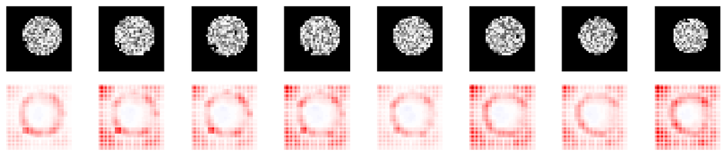

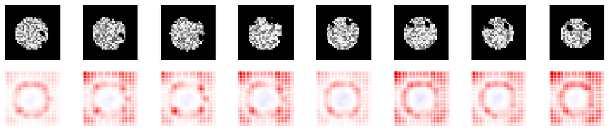

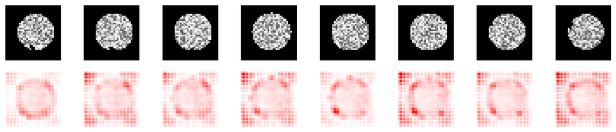

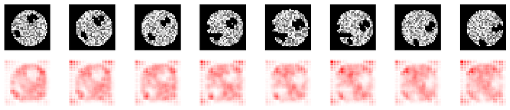

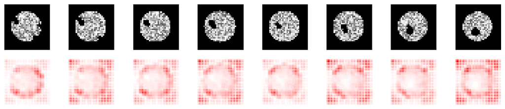

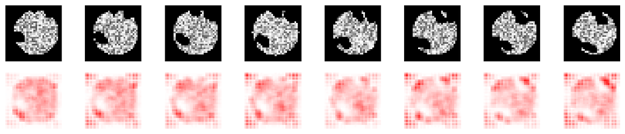

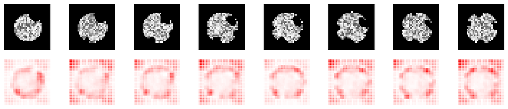

[figure not shown]

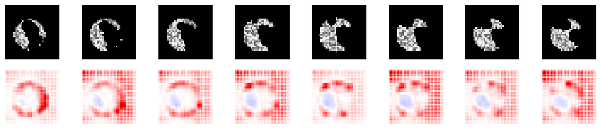

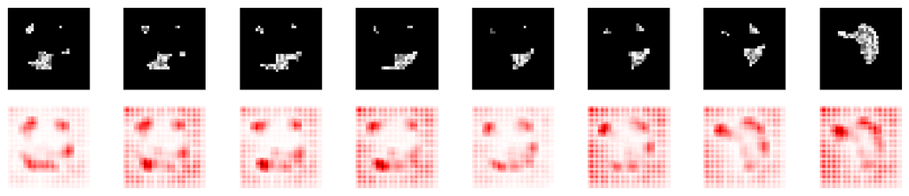

```python
from tensorflow.keras import mixed_precision
from tensorflow.keras.models import clone_model

from explainability import LayerwiseRelevancePropagator, LRPStrategy


# LRP braucht float32 (auch wenn Training mit mixed_float16 lief)
mixed_precision.set_global_policy("float32")
lrp_model = clone_model(model)
lrp_model.set_weights([np.asarray(w, dtype=np.float32) for w in model.get_weights()])

# 6 StandardLRP-Layer: 4× Conv3D + Dense(32) + Dense(1); Pooling zählt nicht
strategy = LRPStrategy(
    layers=[
        {'flat': True},
        {'alpha': 2, 'beta': 1},
        {'alpha': 2, 'beta': 1},
        {'alpha': 2, 'beta': 1},
        {'alpha': 2, 'beta': 1},
        {'epsilon': 0.25},
    ]
)

explainer = LayerwiseRelevancePropagator(lrp_model, layer=-1, idx=0, strategy=strategy)

assert len(test_X) == len(test_y), (
    f"test_X/test_y desynchron: {len(test_X)} vs {len(test_y)} — Split-Zelle neu ausführen"
)
labels = np.asarray(test_y).ravel()
for radius in range(1, MAX_RADIUS + 1):
    matches = np.flatnonzero(labels == radius)
    if matches.size == 0:
        print(f"Skip radius {radius}: kein Sample in test_y")
        continue
    idx = int(matches[0])
    sample = np.asarray(test_X[idx:idx + 1], dtype=np.float32)

    fig, ax = plt.subplots(2, 8, figsize=(15, 3))
    explanations = explainer.predict(sample, verbose=0)
    explanations = explanations / np.amax(np.abs(explanations))

    for j in range(8):
        ax[0][j].imshow(test_X[idx, 12 + j], cmap='Greys_r')
        ax[0][j].axis('off')
        ax[1][j].imshow(explanations[0, 12 + j], cmap='seismic', clim=(-1, 1))
        ax[1][j].axis('off')

plt.show()
```

## 11. Kausaler Test 1: immer mehr Tunnel bohren

↑ Inhaltsverzeichnis

### Die Idee hinter diesem Experiment

Heatmaps sind *korrelativ*: sie zeigen, wo das Netz Relevanz verortet, aber nicht, ob eine Änderung dort die Vorhersage tatsächlich verändert. Der stärkere Test ist ein **kausaler Eingriff**: Man verändert die Eingabe gezielt und beobachtet die Reaktion des Modells. In der XAI-Literatur heißt diese Familie von Tests *perturbation analysis* bzw. *pixel flipping*.

Der Vorteil des synthetischen Datensatzes: wir können den Eingriff *exakt so* durchführen, wie die Daten generiert wurden, und kennen daher die richtige Antwort.

### Was passiert in dieser Zelle?

Es wird **ein** Gehirn gebaut, diesmal mit fixem Mittelpunkt (genau in der Mitte) und fixem Radius, damit keine Störvariation dazukommt. Dann wird in einer Schleife $2 \cdot 6 = 12$-mal ein Tunnel gebohrt — **immer mit derselben Breite `width=5`** — und nach *jedem* Bohrvorgang die Vorhersage abgefragt:

$$p_k = f\big(X_k\big), \qquad k = 1,\dots,12$$

wobei $X_k$ das Volumen mit $k$ Tunneln ist. Wichtig: die Tunnel werden *kumulativ* in dasselbe Volumen gebohrt (`drill` verändert `brain` in place).

### Was wäre das *korrekte* Verhalten?

Hier liegt der didaktische Kern. Das Label hängt nur von der **Breite** ab, nicht von der **Anzahl** der Tunnel. Die Breite bleibt konstant 5. Ein perfektes Modell müsste also eine **waagerechte Linie bei 5** liefern — daher die grüne gestrichelte Referenzlinie im Plot. Jede Steigung ist eine Verletzung der gewünschten *Invarianz gegenüber der Tunnelanzahl*.

Das ist genau die Sorte Fehler, die man in der Praxis fürchtet: das Modell nutzt eine mit dem Ziel korrelierte, aber falsche Größe (hier: den gesamten Gewebeverlust) als Abkürzung — ein **Shortcut** bzw. Confounder. In den Trainingsdaten war die Anzahl immer 6, weshalb das Modell nie lernen musste, die beiden Effekte zu trennen.

### Die Grafiken

**Erstens** eine Reihe von 8 Schnittbildern des *fertigen* Volumens (nach allen 12 Bohrungen): eine kreisförmige Scheibe, in die von allen Seiten schwarze Buchten und Löcher hineinragen. Gut zu sehen ist, wie stark die Kugel nach 12 Tunneln bereits durchlöchert ist, obwohl jeder einzelne Tunnel nur Breite 5 hat.

**Zweitens** der Verlauf der Vorhersage über die Tunnelanzahl. Die gemessenen Werte:

| Tunnel $k$ | 1 | 2 | 3 | 4 | 5 | 6 | 7 | 8 | 9 | 10 | 11 | 12 |
| --- | --- | --- | --- | --- | --- | --- | --- | --- | --- | --- | --- | --- |
| $p_k$ | 0.160 | 0.160 | 0.163 | 0.167 | 0.168 | 0.172 | 0.172 | 0.180 | 0.185 | 0.186 | 0.189 | 0.189 |

### Interpretation

- **Die Richtung ist richtig, die Größenordnung nicht.** Die Kurve steigt monoton: mehr entferntes Gewebe → höhere Vorhersage. Das Modell hat die Grundlogik "*weniger Gewebe bedeutet größeres Label*" verinnerlicht.
- **Die Kurve liegt aber bei ~0.16 bis 0.19, während die Referenzlinie bei 5 liegt.** Im Plot ist die blaue Messkurve deshalb praktisch platt am unteren Rand, weit unter der grünen Linie. Das ist derselbe Kalibrierungsfehler wie im Streudiagramm: der Effekt ist um mehr als einen Faktor 25 zu klein.
- **Der Anstieg ist eine Invarianzverletzung.** Ein austrainiertes Modell sollte hier flach bei 5 verlaufen. Der Anstieg von 0.160 auf 0.189 (+18 %) zeigt, dass die Anzahl der Tunnel mitgemessen wird. Ob das bei 500 Epochen verschwindet, ist eine offene und lohnende Frage — ein sauberer Weg wäre, `NUM_TUNNELS` in den Trainingsdaten zu variieren, damit das Modell die Anzahl als irrelevant lernen *kann*.
- **Ein Darstellungsdetail:** Die x-Werte der Messkurve werden mit `np.arange(1, 41)` erzeugt, es gibt aber nur 12 Messwerte. Plotly zeichnet entsprechend nur 12 Punkte — inhaltlich harmlos, aber die x-Achse suggeriert einen längeren Verlauf, als tatsächlich gemessen wurde.

### Der größere Kontext

Dieser Test ist das synthetische Gegenstück zu einer Frage, die in der medizinischen Bildgebung ständig auftaucht: Reagiert mein Alters-Schätzer auf *Atrophie* oder auf *Kopfgröße*, *Scanner-Modell*, *Bewegungsartefakte*? Da man in echten Daten nicht kontrolliert eingreifen kann, ist das synthetische Setup hier die einzige Möglichkeit, diese Frage sauber zu beantworten.

```
1/1 ━━━━━━━━━━━━━━━━━━━━ 0s 362ms/step
```

```
1/1 ━━━━━━━━━━━━━━━━━━━━ 0s 375ms/step
```

```
1/1 ━━━━━━━━━━━━━━━━━━━━ 0s 16ms/step
```

```
1/1 ━━━━━━━━━━━━━━━━━━━━ 0s 28ms/step
```

```
1/1 ━━━━━━━━━━━━━━━━━━━━ 0s 15ms/step
```

```
1/1 ━━━━━━━━━━━━━━━━━━━━ 0s 28ms/step
```

```
1/1 ━━━━━━━━━━━━━━━━━━━━ 0s 15ms/step
```

```
1/1 ━━━━━━━━━━━━━━━━━━━━ 0s 28ms/step
```

```
1/1 ━━━━━━━━━━━━━━━━━━━━ 0s 16ms/step
```

```
1/1 ━━━━━━━━━━━━━━━━━━━━ 0s 29ms/step
```

```
1/1 ━━━━━━━━━━━━━━━━━━━━ 0s 16ms/step
```

```
1/1 ━━━━━━━━━━━━━━━━━━━━ 0s 28ms/step
```

```
1/1 ━━━━━━━━━━━━━━━━━━━━ 0s 15ms/step
```

```
1/1 ━━━━━━━━━━━━━━━━━━━━ 0s 28ms/step
```

```
1/1 ━━━━━━━━━━━━━━━━━━━━ 0s 15ms/step
```

```
1/1 ━━━━━━━━━━━━━━━━━━━━ 0s 28ms/step
```

```
1/1 ━━━━━━━━━━━━━━━━━━━━ 0s 15ms/step
```

```
1/1 ━━━━━━━━━━━━━━━━━━━━ 0s 28ms/step
```

```
1/1 ━━━━━━━━━━━━━━━━━━━━ 0s 16ms/step
```

```
1/1 ━━━━━━━━━━━━━━━━━━━━ 0s 28ms/step
```

```
1/1 ━━━━━━━━━━━━━━━━━━━━ 0s 15ms/step
```

```
1/1 ━━━━━━━━━━━━━━━━━━━━ 0s 27ms/step
```

```
1/1 ━━━━━━━━━━━━━━━━━━━━ 0s 15ms/step
```

```
1/1 ━━━━━━━━━━━━━━━━━━━━ 0s 28ms/step
```

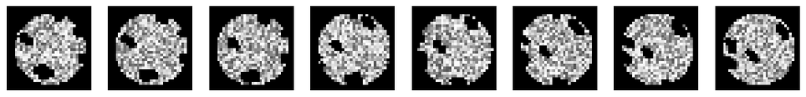

```python
from plotly.colors import DEFAULT_PLOTLY_COLORS


np.random.seed(42)

brain = np.zeros((IMAGE_SIZE, IMAGE_SIZE, IMAGE_SIZE, 1))

center = np.asarray([IMAGE_SIZE // 2 for _ in range(3)])
radius = IMAGE_SIZE // 2-2

idx = np.asarray(np.meshgrid(*[np.arange(IMAGE_SIZE) for _ in range(3)])).T.reshape(-1, 3)
distances = euclidean_distances(idx, center.reshape(1, -1))[:,0]
inside = distances <= radius
surface = np.isclose(distances, radius, atol=1e-1)
surface = idx[surface]

brain[tuple(idx[inside].T)] = np.random.uniform(0.25, 1, (len(idx[inside]), 1))
brain[tuple(idx[surface].T)] = np.random.uniform(0.25, 1, (len(idx[surface]), 1))

inside_keys = set([key(x) for x in idx[inside]])

predictions = []

for _ in range(1, 2 * NUM_TUNNELS + 1):
    brain = drill(brain, surface, center, 5, inside_keys, idx)
    predictions.append(model.predict(np.expand_dims(brain, 0))[0,0])

fig, ax = plt.subplots(1, 8, figsize=(15, 2))

for i in range(8):
    ax[i].imshow(brain[12+i], cmap='Greys_r')
    ax[i].axis('off')

plt.show()

traces = [
    go.Scatter(
        x=np.arange(1, 41),
        y=predictions,
        mode='markers+lines',
        showlegend=False,
        marker={
            'color': DEFAULT_PLOTLY_COLORS[0]
        },
        line={
            'color': DEFAULT_PLOTLY_COLORS[0]
        }
    ),
    go.Scatter(
        x=[1, 2*NUM_TUNNELS],
        y=[5, 5],
        mode='lines',
        showlegend=False,
        line={
            'color': DEFAULT_PLOTLY_COLORS[2],
            'dash': 'dash'
        }
    )
]

layout = go.Layout(
    title={
        'x': 0.5,
        'text': 'Prediction as a function of number of tunnels'
    },
    xaxis={
        'title': 'Number of tunnels'
    },
    yaxis={
        'title': 'Prediction'
    }
)

iplot(go.Figure(traces, layout))
```

## 12. Kausaler Test 2: abwechselnd breite und schmale Tunnel

↑ Inhaltsverzeichnis

### Was wird hier variiert?

Der Aufbau ist derselbe wie in Abschnitt 11, mit einem entscheidenden Unterschied: jetzt bleibt die *Anzahl* der Schritte klein (6), aber die **Breite wechselt**:

$$w_i = 2 + 6\,(i \bmod 2) \;\Longrightarrow\; w = (8,\,2,\,8,\,2,\,8,\,2)$$

Also: Schritte 1, 3, 5 bohren **breite** Tunnel ($w=8$), Schritte 2, 4, 6 bohren **schmale** ($w=2$). Die Marker im Plot sind entsprechend abwechselnd gefärbt.

Damit trennt dieses Experiment die beiden Effekte, die in Abschnitt 11 noch vermischt waren: In *jedem* Schritt kommt ein Tunnel hinzu (Anzahl-Effekt), aber nur in jedem *zweiten* ist er breit (Breiten-Effekt). Wenn das Modell wirklich die Breite misst, dann müssen die **Sprünge nach breiten Bohrungen deutlich größer sein** als nach schmalen — im Idealfall eine Treppe mit Stufen nach oben bei 1, 3, 5 und Plateaus bei 2, 4, 6.

### Die Grafiken

| Schritt | Breite | Vorhersage | Zuwachs $\Delta$ |
| --- | --- | --- | --- |
| 1 | **8** | 0.1847 | — |
| 2 | 2 | 0.1850 | **+0.0003** |
| 3 | **8** | 0.2384 | **+0.0534** |
| 4 | 2 | 0.2437 | +0.0053 |
| 5 | **8** | 0.2546 | **+0.0109** |
| 6 | 2 | 0.2584 | +0.0038 |

### Der größere Kontext

Die beiden Tests der Abschnitte 11 und 12 zusammen sind ein Muster, das sich auf jedes Projekt übertragen lässt:

1. **Verändere die kausal relevante Größe** → das Modell soll stark reagieren.
2. **Verändere eine irrelevante Größe** → das Modell soll *nicht* reagieren.

Erst wenn beide Bedingungen erfüllt sind, hat man Grund, den Heatmaps zu vertrauen. In diesem Durchlauf ist Bedingung 1 ansatzweise erfüllt, Bedingung 2 noch nicht.

```python
np.random.seed(42)

brain = np.zeros((IMAGE_SIZE, IMAGE_SIZE, IMAGE_SIZE, 1))

center = np.asarray([IMAGE_SIZE // 2 for _ in range(3)])
radius = IMAGE_SIZE // 2-2

idx = np.asarray(np.meshgrid(*[np.arange(IMAGE_SIZE) for _ in range(3)])).T.reshape(-1, 3)
distances = euclidean_distances(idx, center.reshape(1, -1))[:,0]
inside = distances <= radius
surface = np.isclose(distances, radius, atol=1e-1)
surface = idx[surface]

brain[tuple(idx[inside].T)] = np.random.uniform(0.25, 1, (len(idx[inside]), 1))
brain[tuple(idx[surface].T)] = np.random.uniform(0.25, 1, (len(idx[surface]), 1))

inside_keys = set([key(x) for x in idx[inside]])

predictions = []

for i in range(1, NUM_TUNNELS + 1):
    width = 2 + (6 * (i % 2))
    brain = drill(brain, surface, center, width, inside_keys, idx)
    predictions.append(model.predict(np.expand_dims(brain, 0))[0,0])

fig, ax = plt.subplots(1, 8, figsize=(15, 2))

for i in range(8):
    ax[i].imshow(brain[12+i], cmap='Greys_r')
    ax[i].axis('off')

plt.show()

colours = [DEFAULT_PLOTLY_COLORS[(i+1) % 2] for i in range(len(predictions))]

traces = [
    go.Scatter(
        x=np.arange(1, NUM_TUNNELS + 1),
        y=predictions,
        mode='markers+lines',
        showlegend=False,
        marker={
            'color': colours
        },
        line={
            'color': DEFAULT_PLOTLY_COLORS[0]
        },
    ),
    go.Scatter(
        x=[1, NUM_TUNNELS],
        y=[5, 5],
        mode='lines',
        showlegend=False,
        line={
            'color': DEFAULT_PLOTLY_COLORS[2],
            'dash': 'dash'
        }
    )
]

layout = go.Layout(
    title={
        'x': 0.5,
        'text': 'Prediction as a function of number of tunnels'
    },
    xaxis={
        'title': 'Number of tunnels'
    },
    yaxis={
        'title': 'Prediction'
    }
)

iplot(go.Figure(traces, layout))
```

[output not shown]

```
1/1 ━━━━━━━━━━━━━━━━━━━━ 0s 16ms/step
```

```
1/1 ━━━━━━━━━━━━━━━━━━━━ 0s 29ms/step
```

```
1/1 ━━━━━━━━━━━━━━━━━━━━ 0s 16ms/step
```

```
1/1 ━━━━━━━━━━━━━━━━━━━━ 0s 29ms/step
```

```
1/1 ━━━━━━━━━━━━━━━━━━━━ 0s 16ms/step
```

```
1/1 ━━━━━━━━━━━━━━━━━━━━ 0s 29ms/step
```

```
1/1 ━━━━━━━━━━━━━━━━━━━━ 0s 15ms/step
```

```
1/1 ━━━━━━━━━━━━━━━━━━━━ 0s 28ms/step
```

```
1/1 ━━━━━━━━━━━━━━━━━━━━ 0s 16ms/step
```

```
1/1 ━━━━━━━━━━━━━━━━━━━━ 0s 28ms/step
```

```
1/1 ━━━━━━━━━━━━━━━━━━━━ 0s 15ms/step
```

```
1/1 ━━━━━━━━━━━━━━━━━━━━ 0s 28ms/step
```

## 13. LRP über das gesamte Volumen

↑ Inhaltsverzeichnis

### Was passiert in dieser Zelle?

Bisher wurden immer nur die acht mittleren Schnitte ($z = 12\dots19$) gezeigt. Jetzt wird das **komplette** Volumen erklärt und alle 32 Schichten geplottet — von $z = 0$ (Rand des Würfels, außerhalb der Kugel) bis $z = 31$.

Erklärt wird das Volumen aus Abschnitt 12, also das mit den abwechselnd breiten und schmalen Tunneln. Zusätzlich werden zwei Schichtindizes automatisch bestimmt:

- `output_layer` — die letzte Schicht, `Dense(1)`, das Erklärungsziel.
- `bottleneck_layer` — die `Dense`-Schicht mit 32 Einheiten. Sie wird in den Abschnitten 14 bis 17 gebraucht. Die Suche per `next(...)` statt einer hartcodierten Zahl ist robuster: bei Änderungen der Architektur verschieben sich Indizes sonst stillschweigend.

### Das Layout der Grafik

Das $8\times8$-Gitter ist **paarweise** zu lesen. Zeilen 1, 3, 5, 7 zeigen Graustufen-Schnitte, Zeilen 2, 4, 6, 8 direkt darunter die zugehörige Relevanz:

| Bildzeile | Inhalt | Schichten |
| --- | --- | --- |
| 1 | Volumen | $z = 0 \dots 7$ |
| 2 | Relevanz | $z = 0 \dots 7$ |
| 3 | Volumen | $z = 8 \dots 15$ |
| 4 | Relevanz | $z = 8 \dots 15$ |
| 5 | Volumen | $z = 16 \dots 23$ |
| 6 | Relevanz | $z = 16 \dots 23$ |
| 7 | Volumen | $z = 24 \dots 31$ |
| 8 | Relevanz | $z = 24 \dots 31$ |

Man liest also immer *ein Bild und das Bild direkt darunter* als Paar.

### Interpretation

  Die `flat`-Regel der ersten Schicht setzt $a \equiv 1$ und $w \equiv 1$ und verteilt Relevanz damit **unabhängig vom Voxelwert** über das rezeptive Feld. Zusammen mit `padding='SAME'` und den Biases kann Relevanz in leere Regionen fließen. Für Einsteiger ist das eine zentrale Lektion:

  > Eine Heatmap zeigt nicht nur das Modell, sondern immer auch die gewählte Erklärungsregel. Was man sieht, ist $\text{Modell} \times \text{Regel}$.

### Praktischer Hinweis

Die auskommentierte Zeile `#plt.savefig('standard.png')` verrät den Zweck dieser Abbildung: Sie ist die "Standard-LRP"-Referenzabbildung, gegen die in den folgenden Abschnitten die *kontrastive* Variante (RestructuredLRP) verglichen werden soll.

```
1/1 ━━━━━━━━━━━━━━━━━━━━ 0s 2s/step
```

```
1/1 ━━━━━━━━━━━━━━━━━━━━ 2s 2s/step
```

[figure not shown]

```python
# Erstes Modell: Output=Dense(1), Bottleneck=Dense(32) ohne built-in Activation
# (RestructuredLRP verlangt lineare Bottleneck-Dense + optionale Activation/Dropout dazwischen)
output_layer = len(model.layers) - 1
bottleneck_layer = next(
    i for i, l in enumerate(model.layers)
    if isinstance(l, Dense) and int(l.units) == 32
)

explainer = LayerwiseRelevancePropagator(
    model, layer=output_layer, idx=0, strategy=strategy
)
explanations = explainer.predict(np.expand_dims(brain, 0))[0]
explanations = explanations / np.amax(np.abs(explanations))

fig, ax = plt.subplots(8, 8, figsize=(15, 8))

for i in range(0, 8, 2):
    for j in range(8):
        idx = ((i // 2) * 8)+ j

        ax[i][j].imshow(brain[idx], cmap='Greys_r')
        ax[i][j].axis('off')
        ax[i+1][j].imshow(explanations[idx], cmap='seismic', clim=(-1, 1))
        ax[i+1][j].axis('off')

#plt.savefig('standard.png')

plt.show()
```

## 14. Der Bottleneck als Repräsentation

↑ Inhaltsverzeichnis

### Was wird berechnet?

Hier wird das Modell **aufgeschnitten**. Mit `Model(model.input, model.layers[bottleneck_layer].output)` entsteht ein neues Keras-Modell, das dieselben Gewichte benutzt, aber nach der `Dense(32)`-Schicht aufhört. Der Fachbegriff dafür ist **Encoder**: er bildet ein Volumen auf einen 32-dimensionalen Vektor ab.

$$z = \mathrm{enc}(X) \in \mathbb{R}^{32}, \qquad \hat{y} = w^\top \mathrm{ReLU}(z) + b$$

Die Interpretation dieser Zerlegung ist wichtig: Das gesamte Netz ist eine Kombination aus einem komplizierten, nichtlinearen **Merkmalsextraktor** und einer ganz einfachen linearen **Ausgabeschicht** darauf. Alles, was das Modell über ein Volumen "weiß", muss durch diesen 32-Zahlen-Engpass. Von $32\,768$ Voxeln auf 32 Zahlen — eine Kompression um Faktor 1024.

Dann wird eine **Referenzgruppe** gebildet: alle Testvolumen mit Label $y = 5$ (also mittlere Tunnelbreite), und davon Mittelwert und Streuung pro Merkmal:

$$\bar{z} = \frac{1}{|G|}\sum_{n \in G} z^{(n)}, \qquad \sigma_k = \sqrt{\frac{1}{|G|}\sum_{n \in G}\big(z^{(n)}_k - \bar{z}_k\big)^2}$$

### Wozu dient das?

$\bar{z}$ ist ein **Prototyp**: "so sieht ein durchschnittliches Gehirn mit Tunnelbreite 5 im Merkmalsraum aus". $\sigma$ beschreibt, wie stark einzelne Merkmale innerhalb dieser Gruppe schwanken, also was noch "normal" ist.

Diese beiden Größen werden im nächsten Abschnitt gebraucht. Der Gedanke dahinter ist der Übergang von einer absoluten zu einer **kontrastiven** Erklärung:

- Standard-LRP beantwortet: "*Warum sagt das Modell diesen Wert?*"
- Kontrastive Erklärung beantwortet: "*Warum sagt das Modell einen **anderen** Wert als bei einem typischen Gehirn der Referenzgruppe?*"

Die zweite Frage ist in der Medizin fast immer die interessantere — man will nicht wissen, was normal ist, sondern was *abweicht*. Es ist auch die Frage, die Menschen von Natur aus stellen: Erklärungen sind fast immer kontrastiv ("*warum X und nicht Y?*").

### Ausgabe

Diese Zelle plottet nichts; sie legt nur `mean_encoding` und `encoding_stddev` für die folgenden Zellen an. Die sichtbare Ausgabe sind lediglich die Fortschrittsbalken von `encoder.predict`.

```python
encoder = Model(model.input, model.layers[bottleneck_layer].output)
encodings = encoder.predict(test_X)
group_idx = np.where(test_y == 5)[0]
group_encodings = encodings[group_idx]
mean_encoding = np.mean(group_encodings, axis=0)
encoding_stddev = np.std(group_encodings, axis=0)
```

```
1/7 ━━━━━━━━━━━━━━━━━━━━ 3s 538ms/step
```

```
7/7 ━━━━━━━━━━━━━━━━━━━━ 0s 86ms/step
```

```
7/7 ━━━━━━━━━━━━━━━━━━━━ 1s 88ms/step
```

## 15. Kontrastive Erklärungen mit RestructuredLRP (deaktiviert)

↑ Inhaltsverzeichnis

### Warum passiert hier nichts?

Der Code dieser Zelle und der nächsten ist in `"""..."""` eingeschlossen, also ein reiner String und damit **wirkungslos**. Die einzige Ausgabe ist der String selbst. Der Grund ist technischer Natur: `RestructuredLRP` stellt zusätzliche Anforderungen an die Architektur (eine *lineare* Bottleneck-`Dense`-Schicht, davor und danach nur Aktivierung/Dropout) und ist mit der aktuellen Keras-Version offenbar noch nicht lauffähig. Die Zellen sind als Dokumentation der Absicht stehen geblieben.

Für das Verständnis lohnt es sich trotzdem, das Konzept anzusehen — es ist der eigentliche methodische Beitrag dieses Repos.

### Die Idee von RestructuredLRP

Standard-LRP verteilt die *ganze* Vorhersage $f(X)$ auf die Voxel. Wenn aber alle Gehirne einen ähnlichen Grundwert erzeugen (etwa "irgendwas um 5"), dann wird die Heatmap von diesem gemeinsamen Anteil dominiert, und der interessante, individuelle Teil geht unter. RestructuredLRP erklärt deshalb nicht $f(X)$, sondern die **Abweichung von einer Referenz**:

$$\Delta = f(X) - f_{\text{ref}} \quad\text{bzw. im Merkmalsraum}\quad \delta_k = z_k - \bar{z}_k$$

Technisch wird der Relevanzfluss am Bottleneck "umgebaut" (daher *restructured*): Statt der absoluten Aktivierung $z_k$ wird die Differenz $z_k - \bar{z}_k$ nach unten propagiert. Die resultierende Heatmap zeigt dann, welche Voxel dieses Gehirn *vom Prototyp unterscheiden*.

Die zweite Zelle geht noch einen Schritt weiter (`threshold=True`) und übergibt zusätzlich `encoding_stddev`. Damit werden Merkmale, die innerhalb der normalen Streuung der Referenzgruppe liegen, **unterdrückt**. Der Gedanke entspricht einem z-Score mit Schwelle:

$$\delta_k^{\text{thresh}} = \begin{cases} z_k - \bar{z}_k & \text{falls } |z_k - \bar{z}_k| > \tau\,\sigma_k \\ 0 & \text{sonst} \end{cases}$$

So bleibt in der Heatmap nur, was **auffällig** ist — statistisches Rauschen innerhalb der Norm wird herausgefiltert.

### Was die Abbildung gezeigt hätte

Die geplante Abbildung hat vier Zeilen, jeweils für die Schnitte $z=12\dots19$:

| Zeile | Inhalt | Frage |
| --- | --- | --- |
| 1 | Volumen (grau) | Was ist zu sehen? |
| 2 | Standard-LRP | Warum dieser Wert? |
| 3 | RestructuredLRP | Warum anders als der Prototyp? |
| 4 | Differenz der Zeilen 3 und 2 | Was fügt die kontrastive Sicht hinzu? |

Die vierte Zeile ist die eigentlich diagnostische: Wo die Differenz null (weiß) ist, liefern beide Verfahren dasselbe; wo sie farbig ist, macht die kontrastive Sicht einen Unterschied. Erwartung wäre, dass die kontrastive Karte *sparsamer* aussieht und stärker auf die Tunnelränder fokussiert, weil der überall gleiche "Kugel-Grundanteil" herausgerechnet ist.

### Der größere Kontext

Kontrastive Erklärungen relativ zu einer gesunden Referenzgruppe sind in der medizinischen Bildanalyse das methodische Ideal: Ein Radiologiebericht sagt nicht "das ist ein Gehirn", sondern "*hier weicht es von der Norm ab*". Verwandte Konzepte, denen man in der Literatur begegnet, sind *Deep Taylor Decomposition* mit Wurzelpunkt (root point), *Integrated Gradients* mit Baseline und *counterfactual explanations*. Allen gemeinsam ist die Frage: **Erklärung im Vergleich zu was?** Genau diese Frage bleibt bei naiver Anwendung von Attributionsmethoden meist unbeantwortet.

```python
"""
from explainability import RestructuredLRP

restructured_lrp = RestructuredLRP(
    model, layer=output_layer, idx=0, bottleneck=bottleneck_layer, strategy=strategy
)
restructured_explanations = restructured_lrp.predict([np.expand_dims(brain, 0),
                                                      np.expand_dims(mean_encoding, 0)])[0]
restructured_explanations = restructured_explanations / np.amax(np.abs(restructured_explanations))

fig, ax = plt.subplots(4, 8, figsize=(15, 4))


for i in range(8):
    ax[0][i].imshow(brain[12+i], cmap='Greys_r')
    ax[0][i].axis('off')
    ax[1][i].imshow(explanations[12+i], cmap='seismic', clim=(-1, 1))
    ax[1][i].axis('off')
    ax[2][i].imshow(restructured_explanations[12+i], cmap='seismic', clim=(-1, 1))
    ax[2][i].axis('off')
    ax[3][i].imshow(restructured_explanations[12+i] - explanations[12+i], cmap='seismic', clim=(-1, 1))
    ax[3][i].axis('off')

plt.show()
"""
```

```
"\nfrom explainability import RestructuredLRP\n    \nrestructured_lrp = RestructuredLRP(\n    model, layer=output_layer, idx=0, bottleneck=bottleneck_layer, strategy=strategy\n)\nrestructured_explanations = restructured_lrp.predict([np.expand_dims(brain, 0), \n                                       …
```

### 15b. Dieselbe Idee mit Schwellenwert (ebenfalls deaktiviert)

↑ Inhaltsverzeichnis

Diese Zelle ist die Variante mit `threshold=True`. Der einzige Unterschied zur vorherigen: es wird zusätzlich `encoding_stddev` übergeben, sodass Merkmale innerhalb der normalen Streuung der Referenzgruppe unterdrückt werden — die im Abschnitt oben beschriebene z-Score-Schwelle. Erwartetes Ergebnis wäre eine deutlich **sparsamere** Heatmap, die nur noch wirklich auffällige Regionen zeigt.

Auch dieser Code ist als String deaktiviert und wird nicht ausgeführt.

```python
"""
from explainability import RestructuredLRP

restructured_lrp = RestructuredLRP(
    model, layer=output_layer, idx=0, bottleneck=bottleneck_layer,
    strategy=strategy, threshold=True
)
restructured_explanations = restructured_lrp.predict([np.expand_dims(brain, 0),
                                                      np.expand_dims(mean_encoding, 0),
                                                      np.expand_dims(encoding_stddev, 0)])[0]
restructured_explanations = restructured_explanations / np.amax(np.abs(restructured_explanations))

fig, ax = plt.subplots(4, 8, figsize=(15, 4))


for i in range(8):
    ax[0][i].imshow(brain[12+i], cmap='Greys_r')
    ax[0][i].axis('off')
    ax[1][i].imshow(explanations[12+i], cmap='seismic', clim=(-1, 1))
    ax[1][i].axis('off')
    ax[2][i].imshow(restructured_explanations[12+i], cmap='seismic', clim=(-1, 1))
    ax[2][i].axis('off')
    ax[3][i].imshow(restructured_explanations[12+i] - explanations[12+i], cmap='seismic', clim=(-1, 1))
    ax[3][i].axis('off')

plt.show()
"""
```

```
"\nfrom explainability import RestructuredLRP\n    \nrestructured_lrp = RestructuredLRP(\n    model, layer=output_layer, idx=0, bottleneck=bottleneck_layer,\n    strategy=strategy, threshold=True\n)\nrestructured_explanations = restructured_lrp.predict([np.expand_dims(brain, 0), \n                  …
```

## 16. Neuronenweise LRP im Bottleneck

↑ Inhaltsverzeichnis

### Was passiert in dieser Zelle?

Bisher wurde immer *die Vorhersage* erklärt. Jetzt wird eine Schicht tiefer gebohrt: Was kodiert eigentlich **jedes einzelne** der 32 Bottleneck-Neuronen?

Dazu wird das Teilmodell `tmp` gebaut, das bei `Dense(32)` endet, und dann in einer Schleife für jedes Neuron $i = 0,\dots,31$ ein eigener Erklärer erzeugt:

```
LayerwiseRelevancePropagator(tmp, layer=len(tmp.layers)-1, idx=i, strategy=strategy)
```

Das Argument `idx=i` wählt aus, *welches* Ausgabeneuron erklärt wird. Intern maskiert LRP alle anderen Ausgaben auf null und propagiert nur die Aktivierung von Neuron $i$ zurück. Das Ergebnis ist eine Heatmap pro Neuron:

$$R^{(i)} = \mathrm{LRP}\big(z_i\big), \qquad \sum_{\text{Voxel } v} R^{(i)}_v \approx z_i$$

Man nennt das *feature visualization by attribution* — man fragt nicht "*warum diese Vorhersage*", sondern "*wann feuert dieses Neuron*".

**Warum hat die Strategie hier nur fünf statt sechs Einträge?** Weil das Teilmodell eine Schicht kürzer ist: 4 Conv-Schichten + `Dense(32)` = 5 Standard-LRP-Schichten. Die `Dense(1)`-Ausgabeschicht und damit ihr $\varepsilon$-Eintrag fehlen. Die Bibliothek prüft das mit einem `assert` — eine falsche Anzahl führt sofort zum Fehler und nicht zu stillschweigend falschen Ergebnissen.

**Die Abbruchbedingung `if np.sum(explanations) == 0: continue`** überspringt Neuronen ohne jede Relevanz, also "tote" Einheiten. In diesem Durchlauf wurden **alle 32 Karten geplottet** — es gibt hier also keine toten Neuronen (das ändert sich in Modell 2, siehe Abschnitt 22).

### Interpretation

  $$z_i = \sum_{c=1}^{64} W_{ci}\, g_c + b_i, \qquad g_c = \text{Mittelwert von Kanal } c$$

  Und weil LRP linear rückverteilt, ist auch jede Neuronen-Heatmap eine Linearkombination derselben 64 Kanal-Relevanzmuster. Die 32 Karten *können* also gar nicht beliebig verschieden sein — sie leben in einem 64-dimensionalen Raum fester Basismuster. Dass sie sich fast nur im Vorzeichen unterscheiden, heißt, dass die Gewichtsvektoren $W_{\cdot i}$ nach zwei Epochen noch stark kollinear sind.
- **Konsequenz:** Global Average Pooling ist gut für Translationsinvarianz, aber schlecht für vielfältige, ortsaufgelöste Merkmale. Genau darum wird in Abschnitt 18 ein zweites Modell ohne GAP gebaut.

### Der größere Kontext

Neuronenweise Analyse ist die Brücke zwischen Attributionsmethoden (die eine *einzelne Vorhersage* erklären) und *mechanistischer Interpretierbarkeit* (die fragt, welche Konzepte ein Netz intern repräsentiert). Verwandte Verfahren: *Network Dissection*, *TCAV* (Testing with Concept Activation Vectors) und *Feature Visualization* durch Optimierung der Eingabe. Die praktische Frage dahinter ist immer dieselbe: Hat das Netz eine reichhaltige, faktorisierte Repräsentation gelernt — oder nur einen einzigen Summenindikator?

[output not shown]

[output not shown]

```
1/1 ━━━━━━━━━━━━━━━━━━━━ 0s 2s/step
```

```
1/1 ━━━━━━━━━━━━━━━━━━━━ 2s 2s/step
```

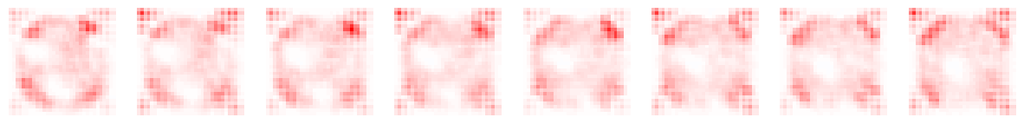

[output not shown]

[output not shown]

```
1/1 ━━━━━━━━━━━━━━━━━━━━ 0s 2s/step
```

```
1/1 ━━━━━━━━━━━━━━━━━━━━ 2s 2s/step
```

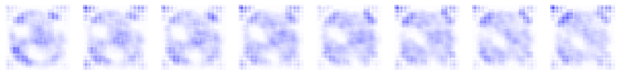

```
1/1 ━━━━━━━━━━━━━━━━━━━━ 0s 2s/step
```

```
1/1 ━━━━━━━━━━━━━━━━━━━━ 2s 2s/step
```

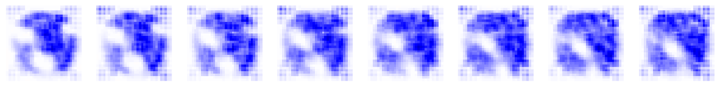

```
1/1 ━━━━━━━━━━━━━━━━━━━━ 0s 2s/step
```

```
1/1 ━━━━━━━━━━━━━━━━━━━━ 2s 2s/step
```

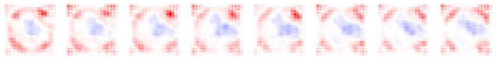

```
1/1 ━━━━━━━━━━━━━━━━━━━━ 0s 2s/step
```

```
1/1 ━━━━━━━━━━━━━━━━━━━━ 2s 2s/step
```

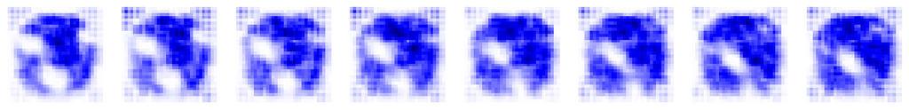

```
1/1 ━━━━━━━━━━━━━━━━━━━━ 0s 2s/step
```

```
1/1 ━━━━━━━━━━━━━━━━━━━━ 2s 2s/step
```

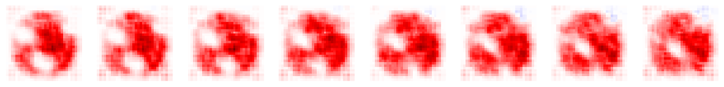

```
1/1 ━━━━━━━━━━━━━━━━━━━━ 0s 2s/step
```

```
1/1 ━━━━━━━━━━━━━━━━━━━━ 2s 2s/step
```

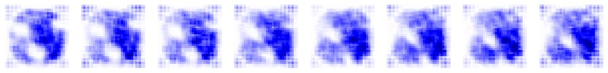

```
1/1 ━━━━━━━━━━━━━━━━━━━━ 0s 2s/step
```

```
1/1 ━━━━━━━━━━━━━━━━━━━━ 2s 2s/step
```

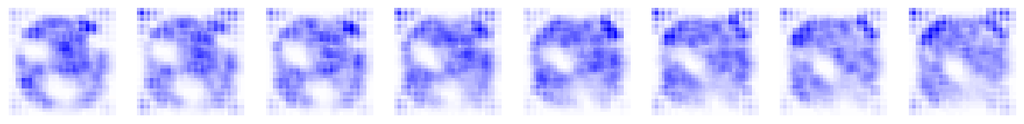

```
1/1 ━━━━━━━━━━━━━━━━━━━━ 0s 2s/step
```

```
1/1 ━━━━━━━━━━━━━━━━━━━━ 2s 2s/step
```

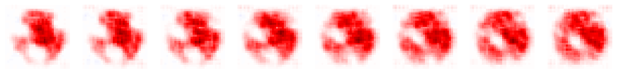

```
1/1 ━━━━━━━━━━━━━━━━━━━━ 0s 2s/step
```

```
1/1 ━━━━━━━━━━━━━━━━━━━━ 2s 2s/step
```

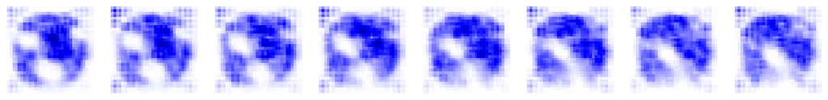

```
1/1 ━━━━━━━━━━━━━━━━━━━━ 0s 2s/step
```

```
1/1 ━━━━━━━━━━━━━━━━━━━━ 2s 2s/step
```

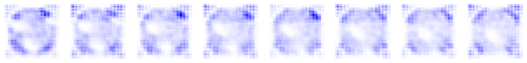

```
1/1 ━━━━━━━━━━━━━━━━━━━━ 0s 2s/step
```

```
1/1 ━━━━━━━━━━━━━━━━━━━━ 2s 2s/step
```

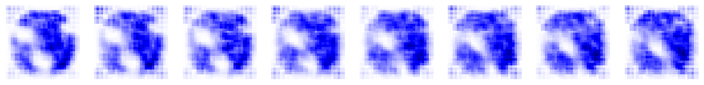

```
1/1 ━━━━━━━━━━━━━━━━━━━━ 0s 2s/step
```

```
1/1 ━━━━━━━━━━━━━━━━━━━━ 2s 2s/step
```

[20 more figures not shown]

```python
tmp = Model(model.input, model.layers[bottleneck_layer].output)

strategy = LRPStrategy(
    layers=[
        {'flat': True},
        {'alpha': 2, 'beta': 1},
        {'alpha': 2, 'beta': 1},
        {'alpha': 2, 'beta': 1},
        {'alpha': 2, 'beta': 1},
    ]
)


fig, ax = plt.subplots(1, 8, figsize=(15, 3))

for i in range(8):
    ax[i].imshow(brain[12+i], cmap='Greys_r')
    ax[i].axis('off')

plt.show()

for i in range(32):
    explainer = LayerwiseRelevancePropagator(
        tmp, layer=len(tmp.layers) - 1, idx=i, strategy=strategy
    )
    explanations = explainer.predict(np.expand_dims(brain, 0))[0]

    if np.sum(explanations) == 0:
        continue

    explanations = explanations / np.amax(np.abs(explanations))

    fig, ax = plt.subplots(1, 8, figsize=(15, 8))

    for j in range(8):
        ax[j].imshow(explanations[12+j], cmap='seismic', clim=(-1, 1))
        ax[j].axis('off')

    plt.show()
```

## 17. Wie redundant sind die 32 Features? Die Korrelationsmatrix

↑ Inhaltsverzeichnis

### Was wird berechnet?

Der Verdacht aus Abschnitt 16 (die Bottleneck-Neuronen sind redundant) wird jetzt quantitativ geprüft. Für alle 600 Trainingsvolumen werden die Encodings berechnet und daraus paarweise die **Pearson-Korrelation** zwischen je zwei Neuronen $i$ und $j$ über die Volumen hinweg:

$$r_{ij} = \frac{\operatorname{Cov}(z_i, z_j)}{\sigma_{z_i}\,\sigma_{z_j}} = \frac{\sum_n (z^{(n)}_i - \bar{z}_i)(z^{(n)}_j - \bar{z}_j)} {\sqrt{\sum_n (z^{(n)}_i - \bar{z}_i)^2}\sqrt{\sum_n (z^{(n)}_j - \bar{z}_j)^2}}$$

Das Ergebnis ist eine symmetrische $32\times32$-Matrix mit Werten in $[-1, 1]$ und Einsen auf der Diagonale. Sie wird als Bild dargestellt.

### Wie man die Grafik liest

- Achsen: Neuronenindex 0 bis 31, beide Achsen identisch belegt.
- Farbskala `viridis` mit `clim=(0, 1)`: **gelb $= r \approx 1$** (perfekt gleichläufig), **grün $\approx 0.7$**, **dunkelblau/violett $= r \le 0$**.
- Wichtige Einschränkung: Wegen `clim=(0, 1)` werden **alle negativen Korrelationen auf dieselbe dunkle Farbe geklemmt**. Ein Neuronenpaar mit $r = -0.98$ (also perfekt gegenläufig und damit genauso redundant!) sieht identisch aus wie ein Paar mit $r = 0$ (unabhängig). Wer Redundanz messen will, sollte $|r|$ plotten oder die Skala auf $[-1, 1]$ setzen. Das ist beim Lesen dieses Bildes unbedingt zu beachten.

### Wie würde man das quantifizieren?

Die Heatmap ist qualitativ. Für eine Zahl bietet sich das Spektrum der Korrelationsmatrix an. Mit den Eigenwerten $\lambda_1 \ge \dots \ge \lambda_{32}$ und $p_k = \lambda_k / \sum_j \lambda_j$ ist die *effektive Dimension* (Beispiel: Entropie-basiert)

$$d_{\text{eff}} = \exp\left(-\sum_{k} p_k \log p_k\right)$$

Bei perfekter Redundanz gilt $d_{\text{eff}} \to 1$, bei völlig unabhängigen Merkmalen $d_{\text{eff}} \to 32$. Alternativ genügt oft schon eine PCA: "*wie viele Komponenten erklären 95 % der Varianz?*"

### Der größere Kontext

Redundanz im Bottleneck hat direkte Folgen für die Erklärbarkeit. Wenn mehrere Neuronen dasselbe kodieren, ist die Aussage "*Neuron 7 kodiert Tunnelbreite*" nicht identifizierbar — man könnte die Information beliebig zwischen den korrelierten Neuronen umverteilen, ohne die Vorhersage zu ändern. Erklärungen auf Neuronenebene sind also nur dann sinnvoll, wenn die Repräsentation halbwegs **entwirrt** (disentangled) ist. Genau deshalb steht diese Analyse im Notebook: sie ist die Voraussetzungsprüfung für alles, was man über einzelne Neuronen behaupten möchte.

```
 1/19 ━━━━━━━━━━━━━━━━━━━━ 0s 19ms/step
```

```
16/19 ━━━━━━━━━━━━━━━━━━━━ 0s 4ms/step
```

```
19/19 ━━━━━━━━━━━━━━━━━━━━ 0s 26ms/step
```

```
19/19 ━━━━━━━━━━━━━━━━━━━━ 1s 27ms/step
```

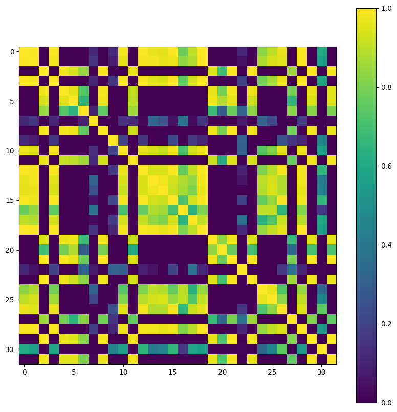

```python
train_encodings = encoder.predict(train_X)

correlations = [[np.corrcoef(train_encodings[:,i], train_encodings[:,j])[0,1] \
                 for i in range(32)] for j in range(32)]

plt.figure(figsize=(10, 10))
heatmap = plt.imshow(correlations, clim=(0, 1))
plt.colorbar(heatmap)
plt.show()
```

## 18. Modell 2: ohne Global Average Pooling, mit fixiertem Bias

↑ Inhaltsverzeichnis

Die Analysen der Abschnitte 13 bis 17 haben zwei Schwächen von Modell 1 aufgedeckt:

1. Die Heatmaps sind räumlich unscharf, weil Global Average Pooling die Ortsinformation wegmittelt.
2. Die Bottleneck-Repräsentation ist stark redundant.

Modell 2 ist die architektonische Antwort darauf. Es ist **kein** besseres Modell im Sinne von "genauer", sondern ein **erklärbarkeitsfreundlicheres**.

### Die beiden entscheidenden Änderungen

**Änderung 1: `Reshape` statt `GlobalAveragePooling3D`.**

```
Modell 1:  ... → (4,4,4,128) → GlobalAveragePooling3D → (64)
Modell 2:  ... → (4,4,4,128) → Reshape → (8192)
```

Anstatt jeden Kanal auf seinen Mittelwert zu reduzieren, wird die komplette Feature-Map "plattgemacht": $4 \cdot 4 \cdot 4 \cdot 128 = 8192$ Werte gehen vollständig in die erste Dense-Schicht. Konsequenzen:

|  | Modell 1 (GAP) | Modell 2 (Reshape) |
| --- | --- | --- |
| Ortsinformation | verworfen | erhalten |
| Translationsinvarianz | ja, per Konstruktion | nein, muss gelernt werden |
| Parameter | 289 089 | **1 348 865** |
| Datenbedarf | niedriger | höher |
| Heatmap-Schärfe | gering | potenziell hoch |

Allein die Schicht `Dense(128)` nach dem Reshape kostet $8192 \cdot 128 + 128 = 1\,048\,704$ Parameter — drei Viertel des gesamten Modells. Das ist der klassische Preis, den man für erhaltene Ortsinformation zahlt, und der Grund, warum moderne Architekturen normalerweise GAP verwenden. Hier nehmen wir ihn bewusst in Kauf, weil LRP nur dann lokalisieren kann, wenn Ortsinformation die letzten Schichten überhaupt erreicht.

**Änderung 2: der auf 5 fixierte Ausgabe-Bias.**

```
Dense(1, activation=None, bias_initializer=Constant([5.]),
      bias_constraint=MinMaxNorm(min_value=5.0, max_value=5.0))
```

Der Bias der Ausgabeschicht wird auf $5$ initialisiert **und** durch einen Constraint dort festgenagelt (Minimum = Maximum = 5, also unveränderlich). Das Modell berechnet damit

$$f(X) = 5 + w^\top h(X)$$

Das ist ein hübscher und lehrreicher Trick mit zwei Effekten:

- **Trainingstechnisch:** $5$ liegt sehr nahe am Mittelwert der Zielverteilung ($\mathbb{E}[y] = 5.5$). Das Modell startet also bereits bei der Mittelwert-Baseline und muss nur noch die *Abweichung* davon lernen. Das erklärt den in Abschnitt 19 sichtbaren, viel besseren Startverlust. Genau dieses Vorgehen (Bias auf den Zielmittelwert initialisieren) ist bei Regression generell empfehlenswert.
- **Erklärungstechnisch:** Der konstante Anteil $5$ trägt keine Relevanz, denn LRP verteilt nur, was durch die Gewichte fließt. Alles, was in der Heatmap erscheint, gehört damit zur Abweichung $w^\top h(X)$ vom Mittelwert. Das Modell ist also **per Konstruktion kontrastiv** — die Heatmaps sind ein Stück weit das, was RestructuredLRP nachträglich erreichen wollte.

### Weitere Unterschiede im Detail

- Nur noch **drei** Conv-Blöcke; die $1\times1\times1$-Conv-Schicht fehlt.
- Dafür ein tieferer Kopf: `Dense(128) → BN → ReLU → Dense(128) → BN → ReLU → Dense(32) → ReLU → Dense(1)`. BatchNorm auch zwischen den Dense-Schichten, weil ein so tiefer, voll verbundener Kopf sonst schlecht konvergiert.
- `Dropout(0.5)` sitzt jetzt *vor* dem ersten `Dense`, also auf 8192 Aktivierungen. Das ist sinnvoll, weil genau dort die Overfitting-Gefahr durch die Million Parameter am größten ist.
- Der Code-Kommentar `Kein BN nach Pooling — fuse_batchnorm kann nur Conv/Dense→BN fusionieren` dokumentiert eine **Einschränkung der LRP-Bibliothek**, die die Architektur mitbestimmt: BatchNorm darf nur direkt hinter einer Conv- oder Dense-Schicht stehen, damit sie beim Erklären hineingerechnet werden kann. Ein gutes Beispiel dafür, dass Erklärbarkeit *Designentscheidungen erzwingt* und nicht nachträglich aufgesetzt werden kann.

### Die Ausgabe: `model.summary()`

**1 348 865 Parameter**, also 4.7-mal so viele wie Modell 1. Man beachte in der Tabelle die Verschiebung des Schwerpunkts: Bei Modell 1 saßen drei Viertel der Parameter in den Conv-Schichten (Merkmalsextraktion), bei Modell 2 sitzen drei Viertel im voll verbundenen Kopf (Klassifikation/Regression aus fertigen Merkmalen). Die Formen zeigen den Schnitt sauber: $(4,4,4,128) \to (8192) \to (128) \to (128) \to (32) \to (1)$.

> **Achtung, eine Notebook-Falle:** Die Variable `model` wird hier **überschrieben**. Alles, was oben mit `model` gemacht wurde (Encoder, Erklärer), bezieht sich ab dieser Zelle auf das *neue* Netz. Führt man die oberen Zellen jetzt noch einmal aus, erklärt man ungewollt Modell 2. Das ist eine der häufigsten Fehlerquellen beim Arbeiten mit Notebooks.

```python
from tensorflow.keras.constraints import MinMaxNorm
from tensorflow.keras.initializers import Constant
from tensorflow.keras.layers import GlobalMaxPooling3D, Reshape


np.random.seed(42)
tf.random.set_seed(42)

regularizer = l2(1e-3)
depths = [32, 64, 128, 256, 256, 64]
activation='relu'
dropout=0.5

inputs = Input((IMAGE_SIZE, IMAGE_SIZE, IMAGE_SIZE, 1))
x = inputs

for i in range(3):
    x = Conv3D(depths[i], (3, 3, 3), padding='SAME',
               activation=None, kernel_regularizer=regularizer,
               bias_regularizer=regularizer)(x)

    x = BatchNormalization()(x)
    x = Activation(activation)(x)
    x = MaxPooling3D((2, 2, 2))(x)

# Kein BN nach Pooling — fuse_batchnorm kann nur Conv/Dense→BN fusionieren
x = Activation(activation)(x)
x = Reshape((-1,))(x)
x = Dropout(dropout)(x)

x = Dense(128, activation=None)(x)
x = BatchNormalization()(x)
x = Activation(activation)(x)
x = Dense(128, activation=None)(x)
x = BatchNormalization()(x)
x = Activation(activation)(x)

x = Dense(32, activation=None)(x)
x = Activation('relu')(x)

x = Dense(1, activation=None, bias_initializer=Constant([5.]),
          bias_constraint=MinMaxNorm(min_value=5.0, max_value=5.0))(x)

model = Model(inputs, x)

model.summary()
```

```
Model: "functional_37"
```

```
┏━━━━━━━━━━━━━━━━━━━━━━━━━━━━━━━━━┳━━━━━━━━━━━━━━━━━━━━━━━━┳━━━━━━━━━━━━━━━┓
┃ Layer (type)                    ┃ Output Shape           ┃       Param # ┃
┡━━━━━━━━━━━━━━━━━━━━━━━━━━━━━━━━━╇━━━━━━━━━━━━━━━━━━━━━━━━╇━━━━━━━━━━━━━━━┩
│ input_layer_1 (InputLayer)      │ (None, 32, 32, 32, 1)  │             0 │
├─────────────────────────────────┼────────────────────────┼───────────────┤
│ conv3d_4 (Conv3D)               │ (None, 32, 32, 32, 32) │           896 │
├─────────────────────────────────┼────────────────────────┼───────────────┤
│ batch_normalization_4           │ (None, 32, 32, 32, 32) │           128 │
│ (BatchNormalization)            │                        │               │
├─────────────────────────────────┼────────────────────────┼───────────────┤
│ activation_5 (Activation)       │ (None, 32, 32, 32, 32) │             0 │
├─────────────────────────────────┼────────────────────────┼───────────────┤
│ max_pooling3d_3 (MaxPooling3D)  │ (None, 16, 16, 16, 32) │             0 │
├─────────────────────────────────┼────────────────────────┼───────────────┤
│ conv3d_5 (Conv3D)               │ (None, 16, 16, 16, 64) │        55,360 │
├─────────────────────────────────┼────────────────────────┼───────────────┤
│ batch_normalization_5           │ (None, 16, 16, 16, 64) │           256 │
│ (BatchNormalization)            │                        │               │
├─────────────────────────────────┼────────────────────────┼───────────────┤
│ activation_6 (Activation)       │ (None, 16, 16, 16, 64) │             0 │
├─────────────────────────────────┼────────────────────────┼───────────────┤
│ max_pooling3d_4 (MaxPooling3D)  │ (None, 8, 8, 8, 64)    │             0 │
├─────────────────────────────────┼────────────────────────┼───────────────┤
│ conv3d_6 (Conv3D)               │ (None, 8, 8, 8, 128)   │       221,312 │
├─────────────────────────────────┼────────────────────────┼───────────────┤
│ batch_normalization_6           │ (None, 8, 8, 8, 128)   │           512 │
│ (BatchNormalization)            │                        │               │
├─────────────────────────────────┼────────────────────────┼───────────────┤
│ activation_7 (Activation)       │ (None, 8, 8, 8, 128)   │             0 │
├─────────────────────────────────┼────────────────────────┼───────────────┤
│ max_pooling3d_5 (MaxPooling3D)  │ (None, 4, 4, 4, 128)   │             0 │
├─────────────────────────────────┼────────────────────────┼───────────────┤
│ activation_8 (Activation)       │ (None, 4, 4, 4, 128)   │             0 │
├─────────────────────────────────┼────────────────────────┼───────────────┤
│ reshape (Reshape)               │ (None, 8192)           │             0 │
├─────────────────────────────────┼────────────────────────┼───────────────┤
│ dropout_1 (Dropout)             │ (None, 8192)           │             0 │
├─────────────────────────────────┼────────────────────────┼───────────────┤
│ dense_2 (Dense)                 │ (None, 128)            │     1,048,704 │
├─────────────────────────────────┼────────────────────────┼───────────────┤
│ batch_normalization_7           │ (None, 128)            │           512 │
│ (BatchNormalization)            │                        │               │
├─────────────────────────────────┼────────────────────────┼───────────────┤
│ activation_9 (Activation)       │ (None, 128)            │             0 │
├─────────────────────────────────┼────────────────────────┼───────────────┤
│ dense_3 (Dense)                 │ (None, 128)            │        16,512 │
├─────────────────────────────────┼────────────────────────┼───────────────┤
│ batch_normalization_8           │ (None, 128)            │           512 │
│ (BatchNormalization)            │                        │               │
├─────────────────────────────────┼────────────────────────┼───────────────┤
│ activation_10 (Activation)      │ (None, 128)            │             0 │
├─────────────────────────────────┼────────────────────────┼───────────────┤
│ dense_4 (Dense)                 │ (None, 32)             │         4,128 │
├─────────────────────────────────┼────────────────────────┼───────────────┤
│ activation_11 (Activation)      │ (None, 32)             │             0 │
├─────────────────────────────────┼────────────────────────┼───────────────┤
│ dense_5 (Dense)                 │ (None, 1)              │            33 │
└─────────────────────────────────┴────────────────────────┴───────────────┘
```

```
 Total params: 1,348,865 (5.15 MB)
```

```
 Trainable params: 1,347,905 (5.14 MB)
```

```
 Non-trainable params: 960 (3.75 KB)
```

## 19. Training von Modell 2

↑ Inhaltsverzeichnis

### Was passiert hier?

Identisches Trainingsrezept wie in Abschnitt 8: MSE-Verlust, Adam mit $10^{-3}$, dieselben Callbacks, dieselben Daten, `epochs=2`. Auch die Seeds sind gleich gesetzt. Das ist gute Experimentierpraxis: Wenn man eine Architektur vergleichen will, muss **alles andere gleich bleiben**, sonst weiß man nicht, woran ein Unterschied liegt.

Auch hier gibt es den Caching-Zweig aus Abschnitt 8, diesmal mit einem eigenen Verzeichnis für Modell 2. Existiert dort schon eine `.keras`-Datei, wird geladen statt trainiert, und es erscheint keine Lernkurve.

### Die Grafik: Lernkurven im direkten Vergleich

[output not shown]

Zur Erinnerung die Referenz: Mittelwert-Baseline $= \operatorname{Var}(y) = 8.25$.

### Interpretation

```python
np.random.seed(42)
tf.random.set_seed(42)

model.compile(loss='mse', optimizer=Adam(1e-3), metrics=['mae'])

callbacks = [
    ReduceLROnPlateau(
        monitor="loss",
        factor=0.1,
        patience=10,
        min_lr=1e-5
    ),
    EarlyStopping(
        monitor="val_loss",
        min_delta=0,
        patience=50,
        restore_best_weights=True
    )
]

MODEL_DIR = target_dir / "model_2_no_gap"
MODEL_DIR.mkdir(parents=True, exist_ok=True)
MODEL_PATH = MODEL_DIR / "brain_regression_no_gap.keras"

existing_model_path = next(iter(sorted(MODEL_DIR.glob("*.keras"))), None)

if existing_model_path is not None:
    model = load_model(existing_model_path)
    history = None
    print(f"Model geladen von: {existing_model_path}")
else:
    history = model.fit(train_X, train_y,
                        validation_data=(val_X, val_y),
                        batch_size=32,
                        epochs=2,
                        #epochs=500,
                        callbacks=callbacks)

    model.save(MODEL_PATH)
    print(f"Model gespeichert unter: {MODEL_PATH}")


if history is None:
    print("Keine Lernkurven: das Modell wurde geladen, nicht trainiert.")
else:
    traces = [
        go.Scatter(
            x=np.arange(len(history.history['loss'])),
            y=history.history['loss'],
            name='Training loss'
        ),
        go.Scatter(
            x=np.arange(len(history.history['loss'])),
            y=history.history['val_loss'],
            name='Validation loss'
        )
    ]

    iplot(go.Figure(traces))
```

[output not shown]

[output not shown]

[output not shown]

[output not shown]

[output not shown]

```
 1/19 ━━━━━━━━━━━━━━━━━━━━ 3:04 10s/step - loss: 7.6942 - mae: 2.3946
```

```
 5/19 ━━━━━━━━━━━━━━━━━━━━ 0s 15ms/step - loss: 7.9994 - mae: 2.4419
```

```
 9/19 ━━━━━━━━━━━━━━━━━━━━ 0s 15ms/step - loss: 7.6943 - mae: 2.3784
```

```
13/19 ━━━━━━━━━━━━━━━━━━━━ 0s 15ms/step - loss: 7.4089 - mae: 2.3252
```

```
17/19 ━━━━━━━━━━━━━━━━━━━━ 0s 15ms/step - loss: 7.1037 - mae: 2.2670
```

[output not shown]

[output not shown]

[output not shown]

```
19/19 ━━━━━━━━━━━━━━━━━━━━ 0s 455ms/step - loss: 6.9583 - mae: 2.2369
```

```
19/19 ━━━━━━━━━━━━━━━━━━━━ 22s 642ms/step - loss: 5.6601 - mae: 1.9667 - val_loss: 8.5152 - val_mae: 2.4993 - learning_rate: 0.0010
```

```
 1/19 ━━━━━━━━━━━━━━━━━━━━ 0s 37ms/step - loss: 2.4331 - mae: 1.2206
```

```
 5/19 ━━━━━━━━━━━━━━━━━━━━ 0s 14ms/step - loss: 2.8138 - mae: 1.3184
```

```
 9/19 ━━━━━━━━━━━━━━━━━━━━ 0s 14ms/step - loss: 2.9000 - mae: 1.3361
```

```
13/19 ━━━━━━━━━━━━━━━━━━━━ 0s 15ms/step - loss: 2.9268 - mae: 1.3452
```

```
17/19 ━━━━━━━━━━━━━━━━━━━━ 0s 15ms/step - loss: 2.9193 - mae: 1.3443
```

```
19/19 ━━━━━━━━━━━━━━━━━━━━ 0s 19ms/step - loss: 2.8298 - mae: 1.3180 - val_loss: 6.7680 - val_mae: 2.2272 - learning_rate: 0.0010
```

```
Model gespeichert unter: /mnt/users/andreasre/git-repos/keras-explainability/output/notebooks/Train_and_explain_synthetic_brain_regression_model/model_2_no_gap/brain_regression_no_gap.keras
```

## 20. LRP für Modell 2

↑ Inhaltsverzeichnis

### Was ist an der Strategie neu?

Die Strategie hat jetzt **sieben** Einträge statt sechs, weil Modell 2 sieben Standard-LRP-Schichten hat (3 Conv + 4 Dense):

| # | Schicht | Regel |
| --- | --- | --- |
| 1 | Conv3D(32) | `flat` |
| 2 | Conv3D(64) | $\alpha=2,\beta=1$ |
| 3 | Conv3D(128) | $\alpha=2,\beta=1$ |
| 4 | Dense(128) | $\alpha=2,\beta=1$ |
| 5 | Dense(128) | $\alpha=2,\beta=1$ |
| 6 | Dense(32) | $\varepsilon=0.25$ |
| 7 | Dense(1) | $\varepsilon=0.25$ |

Das Muster ist typisch und gut zu merken: **`flat` in der Eingabeschicht, $\alpha\beta$ im Faltungsteil, $\varepsilon$ im Kopf.** Begründung: Im Kopf sind die Aktivierungen abstrakt und wenige, dort will man nur numerisch stabilisieren; im Faltungsteil braucht man die kontrastreiche Trennung positiver und negativer Beiträge; in der Eingabeschicht will man Lesbarkeit. `Reshape`, `Dropout`, `Pooling` und `Activation` zählen nicht mit, `BatchNormalization` wird in die vorhergehende Schicht fusioniert.

Erklärt wird wieder dasselbe Volumen wie in Abschnitt 13, sodass die Abbildungen direkt vergleichbar sind. Das Layout ist identisch ($8\times8$, abwechselnd Volumen- und Relevanzzeilen, alle 32 Schichten).

### Interpretation im Vergleich zu Modell 1

```
1/1 ━━━━━━━━━━━━━━━━━━━━ 0s 3s/step
```

```
1/1 ━━━━━━━━━━━━━━━━━━━━ 3s 3s/step
```

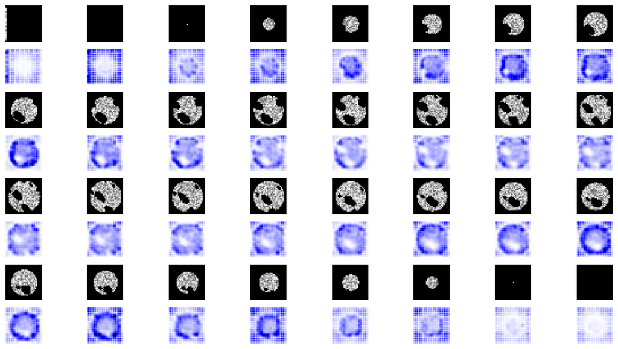

```python
from explainability import LayerwiseRelevancePropagator

strategy = LRPStrategy(
    layers=[
        {'flat': True},
        {'alpha': 2, 'beta': 1},
        {'alpha': 2, 'beta': 1},
        {'alpha': 2, 'beta': 1},
        {'alpha': 2, 'beta': 1},
        {'epsilon': 0.25},
        {'epsilon': 0.25}
    ]
)

# Zweites Modell: Output=Dense(1), Bottleneck=Dense(32) (linear, für RestructuredLRP)
output_layer = len(model.layers) - 1
bottleneck_layer = next(
    i for i, l in enumerate(model.layers)
    if isinstance(l, Dense) and int(l.units) == 32
)

explainer = LayerwiseRelevancePropagator(
    model, layer=output_layer, idx=0, strategy=strategy
)
explanations = explainer.predict(np.expand_dims(brain, 0))[0]
explanations = explanations / np.amax(np.abs(explanations))

fig, ax = plt.subplots(8, 8, figsize=(15, 8))

for i in range(0, 8, 2):
    for j in range(8):
        idx = ((i // 2) * 8)+ j

        ax[i][j].imshow(brain[idx], cmap='Greys_r')
        ax[i][j].axis('off')
        ax[i+1][j].imshow(explanations[idx], cmap='seismic', clim=(-1, 1))
        ax[i+1][j].axis('off')

plt.show()
```

## 21. Neuronenweise LRP für Modell 2

↑ Inhaltsverzeichnis

### Was passiert hier?

Dieselbe Analyse wie in Abschnitt 16, jetzt für Modell 2: für jedes der 32 Bottleneck-Neuronen eine eigene Heatmap. Die Strategie hat sechs Einträge, weil das Teilmodell bis `Dense(32)` sechs Standard-LRP-Schichten enthält (3 Conv + `Dense(128)` + `Dense(128)` + `Dense(32)`); der Eintrag für die `Dense(1)`-Ausgabeschicht fällt weg.

Der Sinn der Wiederholung: **Hat der Architekturwechsel die Redundanz aufgelöst?** Bei Modell 1 waren alle 32 Karten praktisch identisch, weil Global Average Pooling jedes Bottleneck-Neuron auf eine Linearkombination von nur 64 Kanalmittelwerten reduzierte. Ohne GAP steht dem Kopf jetzt der volle $8192$-dimensionale Merkmalsvektor zur Verfügung — die Neuronen *könnten* also ortsspezifisch werden.